← Go back to Home

# **Deep Learning-Based Product Image Classifier for Artiszën Crafts**

### IST 691 Deep Learning – Final Project

**Due: June 20, 2025**  
**Team Members**

- Neysha Pagán (Infrastructure & Project Lead)
- Philippe Louis Jr (Model Design & Tuning)
- Andrew Zhang (Training Setup & Evaluation)
- Anthony Thomas (Data Augmentation & Deployment)

## Project Objective

This project aims to build a deep learning model that can automatically classify product media (images/videos) from Artiszen Crafts into categories like mugs, resin, shirts, etc.

We will ingest and label real product photos/videos, then use a CNN model with transfer learning to train an image classifier.  
This will help automate the tagging and cataloging process for potential e-commerce integrations like Shopify.

## Connecting Google Colab to PostgreSQL using ngrok

To enable remote access to a local PostgreSQL server from Google Colab, you must expose your local database using a secure tunnel. This is done using ngrok, a tunneling tool that creates a public TCP address that Colab can connect to.

⚠️ Important Note: If your ngrok session expires due to inactivity or you restart it, the tcp address and port number will likely change. Make sure to update your connection parameters accordingly in your notebook.

🛠️ What This Setup Does

- Uses ngrok to expose your local PostgreSQL port 5432 to the public internet
- Allows Google Colab to securely connect to your local database
- Enables data pipelines and SQL queries directly from Colab notebooks

📦 Step 1: Download and Install ngrok Visit the official site and download ngrok for your OS: 🔗 https://ngrok.com/download

Unzip the downloaded file and place the ngrok binary somewhere in your system's PATH.

🔐 Step 2: Authenticate ngrok (only once) Create a free account at ngrok.com to get your auth token.

Then run the following in your terminal:

```
ngrok config add-authtoken YOUR_NGROK_AUTH_TOKEN
```

## Install Dependencies & Import Required Libraries

Before connecting to PostgreSQL or running any data processing, we must install the necessary Python packages and import all required libraries for:

- Database connection and query execution using psycopg2
- Secure password input via getpass
- Google Drive mounting in Colab using google.colab.drive
- Data analysis and visualization with pandas and matplotlib
- Display enhancements using IPython.display

```python
# Install dependencies

!pip install psycopg2-binary
!pip install tensorflow
!pip install torch torchvision
```

```python
!pip install tensorflow
!pip install torch torchvision
```

```python
# Import all the required libraries

import os
import getpass
import psycopg2
import traceback
from psycopg2.extras import execute_values
from google.colab import drive
import pandas as pd
import matplotlib.pyplot as plt
from IPython.display import display
import cv2
from torch.utils.data import Dataset, DataLoader, WeightedRandomSampler
import albumentations as A
from albumentations.pytorch import ToTensorV2
from PIL import Image
from sklearn.model_selection import train_test_split
from sklearn.metrics import classification_report, confusion_matrix
import torch
import torchvision
import torchvision.models as torchmodels
import torch.nn as nn
import torch.nn.functional as F
import torch.optim as optim
import torchvision.models as models
from torchvision.models import resnet18, ResNet18_Weights
import numpy as np
from sklearn.preprocessing import LabelEncoder
from sklearn.metrics import accuracy_score
from tensorflow.keras.applications import ResNet50
from tensorflow.keras import layers, models
from tensorflow.keras.optimizers import Adam
from tensorflow.keras.utils import to_categorical
import tensorflow as tf
import matplotlib.pyplot as plt
from tensorflow.keras import layers, models, optimizers
import seaborn as sns
from datetime import datetime
import random
from torch.nn import CrossEntropyLoss
from io import BytesIO
from io import StringIO
from sqlalchemy import create_engine
```

## PostgreSQL Schema Setup

This section sets up the database to store media metadata (images/videos).

🔐 connect_to_postgres()

- Connects securely to a remote PostgreSQL database using ngrok.

  ⚠️ Important Note: If ngrok restarts, update the host and port values.

🗂️ create_media_schema_and_tables(conn)

- Creates the media schema and 3 tables:
  - product_category: Stores category info.
  - media_files: Stores file paths and metadata.
  - media_labels: Stores labels for media items.

🔒 add_unique_constraints(conn)

- Adds unique constraints to:
  - Prevent duplicate media entries.
  - Prevent duplicate labels per media file.

🧹 truncate_all_media_tables(conn)

- (Development only) Clears all media tables and resets IDs.

```python
# Defining Database Setup Functions

# ---------------------- DB Connection ----------------------
def connect_to_postgres():
    DB_HOST = "4.tcp.ngrok.io"
    DB_PORT = "11218"
    DB_NAME = "artiszen_db"
    DB_USER = input("Enter PostgreSQL username: ")
    DB_PASS = getpass.getpass("Enter PostgreSQL password: ")

    try:
        conn = psycopg2.connect(
            host=DB_HOST,
            port=DB_PORT,
            dbname=DB_NAME,
            user=DB_USER,
            password=DB_PASS
        )
        print(f"✅ Connected as '{DB_USER}'.")
        return conn
    except Exception as e:
        print("❌ Connection failed:", e)
        return None

# ---------------------- Create Schema & Tables ----------------------
def create_media_schema_and_tables(conn):
    cur = conn.cursor()

    cur.execute("""
    CREATE SCHEMA IF NOT EXISTS media;
    """)

    cur.execute("""
    CREATE TABLE IF NOT EXISTS media.product_category (
        category_id SERIAL PRIMARY KEY,
        category_name VARCHAR(100) UNIQUE NOT NULL,
        has_images BOOLEAN DEFAULT TRUE,
        has_videos BOOLEAN DEFAULT FALSE
    );
    """)

    cur.execute("""
    CREATE TABLE IF NOT EXISTS media.media_files (
        media_id SERIAL PRIMARY KEY,
        file_name TEXT NOT NULL,
        file_path TEXT NOT NULL,
        file_type VARCHAR(10) CHECK (file_type IN ('image', 'video')),
        category_id INT REFERENCES media.product_category(category_id),
        created_at TIMESTAMP DEFAULT CURRENT_TIMESTAMP
    );
    """)

    cur.execute("""
    CREATE TABLE IF NOT EXISTS media.media_labels (
        label_id SERIAL PRIMARY KEY,
        media_id INT REFERENCES media.media_files(media_id),
        label TEXT NOT NULL,
        confidence FLOAT,
        created_by TEXT,
        created_at TIMESTAMP DEFAULT CURRENT_TIMESTAMP
    );
    """)

    conn.commit()
    cur.close()
    print("✅ Schema and tables verified or created.")

# ---------------------- Unique Constraint Setup ----------------------
def add_unique_constraints(conn):
    cur = conn.cursor()
    try:
        # Unique on media_files
        cur.execute("""
            ALTER TABLE media.media_files
            ADD CONSTRAINT uq_media_file
            UNIQUE (file_name, file_path, file_type, category_id);
        """)
    except Exception as e:
        conn.rollback()
        if "already exists" not in str(e):
            print("⚠️ Error adding uq_media_file:", e)
    else:
        conn.commit()

    try:
        # Unique on media_labels: media_id + label
        cur.execute("""
            ALTER TABLE media.media_labels
            ADD CONSTRAINT uq_media_label
            UNIQUE (media_id, label);
        """)
    except Exception as e:
        conn.rollback()
        if "already exists" not in str(e):
            print("⚠️ Error adding uq_media_label:", e)
    else:
        conn.commit()

    cur.close()
    print("✅ Unique constraints for media_files and media_labels verified/created.")

# ---------------------- Truncate Tables (optional) ----------------------
def truncate_all_media_tables(conn):
    cur = conn.cursor()
    try:
        cur.execute("""
        TRUNCATE TABLE
            media.media_labels,
            media.media_files,
            media.product_category
        RESTART IDENTITY CASCADE;
        """)
        conn.commit()
        print("🧹 Tables truncated.")
    except Exception as e:
        print("❌ Truncate failed:", e)
    cur.close()
```

## 📁 Connect Google Drive & Define Dataset Paths

We mount Google Drive into the Colab environment so we can access the dataset located under `/MyDrive/DL/artiszen_media/`.

Here, we define:

- `base_dir`: the root path
- `image_dir` and `video_dir`: where the media files are stored in subfolders by category

```python
# Mount Google Drive

drive.mount('/content/drive')
```

```python
# Define path for folders

base_dir = "/content/drive/MyDrive/DL/artiszen_media"
image_dir = base_dir + "/artiszen_dataset_images"
video_dir = base_dir + "/artiszen_dataset_videos"

print("📁 Image folder exists:", os.path.exists(image_dir))
print("📁 Video folder exists:", os.path.exists(video_dir))
```

```
📁 Image folder exists: True
📁 Video folder exists: True
```

## 🧾 Data Ingestion Pipeline Summary (Structured Markdown & Code Guidance)

This section describes the three main ingestion stages for the Artiszen Crafts Deep Learning Classifier project. Each step includes a dedicated function and description to keep your notebook clean and modular.

🗂️ Step 1: Insert Product Categories

We scan both `image_dir` and `video_dir` to extract unique category names (e.g., mugs, resin, shirts). These are inserted into the `media.product_category` table with two flags:

- `has_images` — if the category appears under the image folder
- `has_videos` — if the category appears under the video folder

Duplicates are resolved using `ON CONFLICT DO UPDATE`, ensuring idempotent behavior.

🛠️ Function to use:

```
insert_categories(conn, image_dir, video_dir)
```

🖼️ Step 2: Insert Media Files (Images + Videos) Each image/video file is inserted into media.media_files with:

- file name
- relative path
- type: 'image' or 'video'
- foreign key to its category_id
- A UNIQUE constraint on (file_name, file_path, file_type, category_id) prevents duplicates.

🛠️ Function to use:

```
insert_media_files(conn, image_dir, video_dir, base_dir)
```

🏷️ Step 3: Insert Temporary Labels (auto-category) To prepare the dataset for model training, we populate media.media_labels with initial labels derived from the product category.

Each file receives:

- label = category name
- confidence = 1.0
- created_by = 'auto-category'
- Duplicates are avoided with ON CONFLICT DO NOTHING.

🛠️ Function to use:

```
insert_temp_labels(conn)
```

```python
# Defining Data Insertion Functions

# ------------------ Insert or Update Categories ------------------
def insert_categories(conn, image_dir, video_dir):
    cur = conn.cursor()
    try:
        image_categories = set(os.listdir(image_dir))
        video_categories = set(os.listdir(video_dir))
        all_categories = sorted(image_categories | video_categories)

        values = []
        for cat in all_categories:
            has_images = cat in image_categories
            has_videos = cat in video_categories
            values.append((cat.lower(), has_images, has_videos))

        print("🧪 Categories to insert:")
        for v in values:
            print("   ", v)

        insert_cat_query = """
        INSERT INTO media.product_category (category_name, has_images, has_videos)
        VALUES %s
        ON CONFLICT (category_name) DO UPDATE
        SET has_images = EXCLUDED.has_images,
            has_videos = EXCLUDED.has_videos;
        """
        execute_values(cur, insert_cat_query, values)
        print(f"✅ Inserted/updated {len(values)} categories.")
        conn.commit()
    except Exception as e:
        conn.rollback()
        print("❌ Error inserting categories:", e)
        raise
    finally:
        cur.close()

# ------------------ Helper Function: Collect Nested Files ------------------
def collect_nested_files(cur, root_folder, media_type, valid_exts, base_dir):
    collected = []
    for category in os.listdir(root_folder):
        cat_folder = os.path.join(root_folder, category)
        if not os.path.isdir(cat_folder):
            continue

        cur.execute("SELECT category_id FROM media.product_category WHERE category_name = %s", (category.lower(),))
        result = cur.fetchone()
        if not result:
            print(f"⚠️ Category '{category}' not found. Skipping.")
            continue
        category_id = result[0]

        count = 0
        for subdir, _, files in os.walk(cat_folder):
            for f in files:
                ext = os.path.splitext(f)[1].lower()
                if ext not in valid_exts:
                    continue
                abs_path = os.path.join(subdir, f)
                rel_path = os.path.relpath(abs_path, base_dir).replace("\\", "/")
                collected.append((f, rel_path, media_type, category_id))
                count += 1
        print(f"📂 {category.lower()} [{media_type}]: {count} file(s)")
    return collected

# ------------------ Insert or Update Media Files ------------------
def insert_media_files(conn, image_dir, video_dir, base_dir):
    cur = conn.cursor()
    try:
        image_exts = {".jpg", ".jpeg", ".png", ".gif", ".bmp", ".tiff", ".webp"}
        video_exts = {".mp4", ".mov", ".avi", ".mkv", ".wmv", ".flv", ".webm"}
        records = []
        records += collect_nested_files(cur, image_dir, "image", image_exts, base_dir)
        records += collect_nested_files(cur, video_dir, "video", video_exts, base_dir)

        if records:
            invalid_records = [r for r in records if None in r]
            if invalid_records:
                print(f"❌ Found {len(invalid_records)} invalid record(s) with NULL values. Aborting insert.")
                for r in invalid_records[:5]:
                    print("❗", r)
                raise ValueError("Found invalid records with NULLs.")

            print("🔍 First 5 valid records:")
            for r in records[:5]:
                print(r, type(r))

            insert_media_query = """
            INSERT INTO media.media_files (file_name, file_path, file_type, category_id)
            VALUES %s
            ON CONFLICT (file_name, file_path, file_type, category_id)
            DO UPDATE SET
                file_name = EXCLUDED.file_name,
                file_path = EXCLUDED.file_path,
                file_type = EXCLUDED.file_type,
                category_id = EXCLUDED.category_id;
            """
            execute_values(cur, insert_media_query, records)
            print(f"✅ Total media files inserted/updated: {len(records)}")
        else:
            print("⚠️ No media files to insert.")

        conn.commit()
    except Exception as e:
        traceback.print_exc()
        conn.rollback()
        print("❌ Error inserting media files:", e)
        raise
    finally:
        cur.close()

# ------------------ Insert or Update Temporary Labels ------------------
def insert_temp_labels(conn):
    cur = conn.cursor()
    try:
        cur.execute("""
            INSERT INTO media.media_labels (media_id, label, confidence, created_by)
            SELECT mf.media_id, pc.category_name, 1.0, 'auto-category'
            FROM media.media_files mf
            JOIN media.product_category pc ON mf.category_id = pc.category_id
            ON CONFLICT (media_id, label) DO UPDATE
            SET confidence = EXCLUDED.confidence,
                created_by = EXCLUDED.created_by;
        """)
        conn.commit()
        print("✅ Temporary labels inserted/updated.")
    except Exception as e:
        conn.rollback()
        print("❌ Error inserting labels:", e)
        raise
    finally:
        cur.close()
```

### Full Ingestion Pipeline Overview

This function, `run_full_ingestion_pipeline()`, orchestrates the entire metadata ingestion process for the Artiszen Crafts deep learning project. It is responsible for:

1. **Category Synchronization** It reads all folder names from the image and video directories and inserts them into the `media.product_category` table.
   - If a category already exists, it updates its `has_images` and `has_videos` flags.
   - This ensures the table reflects all categories and their media availability.
2. **Media File Ingestion** The script recursively scans each category folder and collects valid media files (e.g., `.jpg`, `.png`, `.mp4`, etc.). For each file:
   - It constructs a relative path
   - Associates it with the correct category ID
   - Inserts or updates the metadata into the `media.media_files` table Uniqueness is enforced on `(file_name, file_path, file_type, category_id)` via a **unique constraint**.
3. **Temporary Label Assignment** After ingesting media files, each file is labeled with its category name and inserted into `media.media_labels`.
   - These labels are placeholders used for training
   - `confidence = 1.0` and `created_by = 'auto-category'`
   - If a label already exists, it is updated to ensure consistency
4. **Resilient Error Handling** If any error occurs (e.g., during insertion), the transaction is rolled back using `conn.rollback()` to preserve database integrity. Connection health is checked at each stage, and reconnection is attempted if needed.

This pipeline is designed to be **idempotent**: running it multiple times will not duplicate records or corrupt the database.

```python
def run_full_ingestion_pipeline(conn, image_dir, video_dir, base_dir):
    if conn is None or conn.closed != 0:
        print("❌ Invalid or closed database connection.")
        return None

    # STEP 1: Insert Categories
    try:
        insert_categories(conn, image_dir, video_dir)
    except Exception as e:
        print("⛔ insert_categories() failed:", e)
        conn.rollback()
        print("ℹ️ Rolled back transaction after failure in categories.")
        return None

    # STEP 2: Insert Media Files
    try:
        insert_media_files(conn, image_dir, video_dir, base_dir)
    except Exception as e:
        print("⛔ insert_media_files() failed:", e)
        conn.rollback()
        print("ℹ️ Rolled back transaction after failure in media files.")
        return None

    # STEP 3: Insert Temporary Labels
    try:
        insert_temp_labels(conn)
    except Exception as e:
        print("⛔ insert_temp_labels() failed:", e)
        conn.rollback()
        print("ℹ️ Rolled back transaction after failure in temp labels.")
        return None

    print("✅ All steps in ingestion pipeline completed successfully.")
    return conn
```

## 🔄 Defining main()

The `main()` function orchestrates the entire ingestion pipeline for the Artiszen Crafts media classification project. It performs the following steps:

1. **Mount Google Drive (Colab Only):**  
   Ensures access to the dataset stored in Google Drive for cloud-based notebooks like Google Colab.
2. **Define Paths for Media Files:**  
   Sets the `base_dir`, `image_dir`, and `video_dir` pointing to the dataset location inside Drive. It validates whether these folders exist and logs their status.
3. **Establish PostgreSQL Connection:**  
   Prompts the user for secure credentials and attempts to connect to the PostgreSQL database using `connect_to_postgres()`.
4. **Initialize Database Schema and Tables:**  
   If the connection is successful, the function creates the schema `media` (if not already present), the core tables (`product_category`, `media_files`, and `media_labels`), and a unique constraint for avoiding duplicate entries.
5. **(Optional) Truncate Existing Data:**  
   You may uncomment the line `truncate_all_media_tables()` if a clean slate is needed before re-running the pipeline.
6. **Run Ingestion Pipeline:**  
   Calls `run_full_ingestion_pipeline()` to:
   - Insert or update category metadata
   - Insert or update media file metadata
   - Auto-generate temporary labels for classification
7. **Graceful Completion:**  
   After ingestion, the connection is closed properly, and final status messages are printed to confirm successful execution.

### 🎯 Outcome:

By running this function, all image and video files in the Artiszen dataset are inserted or updated in the database, with auto-labeled categories assigned for later training in the deep learning model.

```python
def main():

    print("🚀 Starting media ingestion pipeline...")

    try:
        # Mount Google Drive
        print("🔄 Mounting Google Drive...")
        drive.mount('/content/drive')
    except Exception as e:
        print("❌ Failed to mount Google Drive:", e)
        return

    try:
        # Define Media Paths
        base_dir = "/content/drive/MyDrive/DL/artiszen_media"
        image_dir = base_dir + "/artiszen_dataset_images"
        video_dir = base_dir + "/artiszen_dataset_videos"

        if not os.path.exists(image_dir) or not os.path.exists(video_dir):
            raise FileNotFoundError("Image or video directory not found.")

        print("📁 Image folder exists:", os.path.exists(image_dir))
        print("📁 Video folder exists:", os.path.exists(video_dir))
    except Exception as e:
        print("❌ Failed to verify media paths:", e)
        return

    try:
        # Connect to PostgreSQL
        conn = connect_to_postgres()
        if conn is None or conn.closed != 0:
            raise ConnectionError("Failed to connect to PostgreSQL.")
        print("✅ PostgreSQL connection established.")
    except Exception as e:
        print("❌ PostgreSQL connection error:", e)
        return

    try:
        # Create schema, tables, and unique constraints
        print("🧱 Creating schema and tables...")
        create_media_schema_and_tables(conn)
        add_unique_constraints(conn)
        #truncate_all_media_tables(conn)  # Optional
    except Exception as e:
        conn.rollback()
        print("❌ Failed during schema setup:", e)
        conn.close()
        return

    try:
        # Run full ingestion pipeline
        print("📥 Running ingestion pipeline...")
        conn = run_full_ingestion_pipeline(
            conn=conn,
            image_dir=image_dir,
            video_dir=video_dir,
            base_dir=base_dir
        )
        if conn:
            print("🎉 Main pipeline finished successfully.")
            conn.close()
        else:
            print("⚠️ Ingestion completed with connection issues.")

    except Exception as e:
        conn.rollback()
        print("❌ Pipeline execution failed:", e)
        conn.close()
```

```python
# Run the pipeline
main()
```

[output not shown]

## Exploratory Data Analysis

This section performs an initial exploratory analysis of the media ingestion results to verify data quality, completeness, and distribution across categories and file types.

We cover the following:

📥 Data Loading:

- Connect to the PostgreSQL database and load the three main tables into Pandas DataFrames:
  - media_files: Metadata for all images and videos
  - product_category: List of categories (e.g., shirts, mugs)
  - media_labels: Initial auto-generated labels

🔍 Data Preview:

- Display sample records from each table to verify content integrity and structure.

📈 Category File Counts:

- Aggregate the number of media files per category and display a sorted table with counts.

📊 Visual Analysis - Files per Category:

- Generate a bar chart to visualize how many files are stored per product category. This helps identify any underrepresented or overrepresented categories.

📊 Visual Analysis - Files by Type:

- Plot a second bar chart showing the distribution of media types (image vs video), to confirm ingestion balance and file diversity.

These EDA steps ensure that the ingestion pipeline executed correctly and provide insight into the current dataset structure before training the model.

```
=== Media Files Sample ===
```

|  | media_id | file_name | file_path | file_type | category_id | created_at |
| --- | --- | --- | --- | --- | --- | --- |
| 0 | 1 | MG2301IMGIflintstones12ozBLK.jpg | artiszen_dataset_images/mugs/MG2301IMGIflintst... | image | 9 | 2025-06-20 01:59:25.470238 |
| 1 | 2 | MG2201IMGpochacco12ozWHT.jpg | artiszen_dataset_images/mugs/MG2201IMGpochacco... | image | 9 | 2025-06-20 01:59:25.470238 |
| 2 | 3 | MG2201IMGspottiedot12ozWHT.jpg | artiszen_dataset_images/mugs/MG2201IMGspottied... | image | 9 | 2025-06-20 01:59:25.470238 |
| 3 | 4 | MG2201IMGhellokitty12ozWHT.jpg | artiszen_dataset_images/mugs/MG2201IMGhellokit... | image | 9 | 2025-06-20 01:59:25.470238 |
| 4 | 5 | MG2501IMGstitch12ozBLK.jpg | artiszen_dataset_images/mugs/MG2501IMGstitch12... | image | 9 | 2025-06-20 01:59:25.470238 |
| 5 | 6 | AG25A5flowers.jpg | artiszen_dataset_images/agendas/AG25A5flowers.jpg | image | 1 | 2025-06-20 01:59:25.470238 |
| 6 | 7 | AG25A5fridak.jpg | artiszen_dataset_images/agendas/AG25A5fridak.jpg | image | 1 | 2025-06-20 01:59:25.470238 |
| 7 | 8 | S25teacher3in.jpg | artiszen_dataset_images/stickers/S25teacher3in... | image | 12 | 2025-06-20 01:59:25.470238 |
| 8 | 9 | S25morewords2in.jpg | artiszen_dataset_images/stickers/S25morewords2... | image | 12 | 2025-06-20 01:59:25.470238 |
| 9 | 10 | STH25abelynda3insq.jpg | artiszen_dataset_images/stickers/STH25abelynda... | image | 12 | 2025-06-20 01:59:25.470238 |

```
=== Categories ===
```

|  | category_id | category_name | has_images | has_videos |
| --- | --- | --- | --- | --- |
| 0 | 1 | agendas | True | True |
| 1 | 2 | bundles | True | False |
| 2 | 3 | business cards | True | False |
| 3 | 4 | dft_prints | False | True |
| 4 | 5 | dtf_prints | True | False |
| 5 | 6 | hats | True | False |
| 6 | 7 | laser | True | False |
| 7 | 8 | misc | True | False |
| 8 | 9 | mugs | True | True |
| 9 | 10 | resin | True | True |
| 10 | 11 | shirts | True | True |
| 11 | 12 | stickers | True | False |
| 12 | 13 | sublimation | True | False |
| 13 | 14 | tumblers | True | True |
| 14 | 15 | uvdtf | True | False |

```
=== Media Labels Sample ===
```

|  | label_id | media_id | label | confidence | created_by | created_at | new_label | official_label | updated_date |
| --- | --- | --- | --- | --- | --- | --- | --- | --- | --- |
| 0 | 1 | 1 | mugs | 1.0 | auto-category | 2025-06-20 01:59:27.230310 | None | None | None |
| 1 | 2 | 2 | mugs | 1.0 | auto-category | 2025-06-20 01:59:27.230310 | None | None | None |
| 2 | 3 | 3 | mugs | 1.0 | auto-category | 2025-06-20 01:59:27.230310 | None | None | None |
| 3 | 4 | 4 | mugs | 1.0 | auto-category | 2025-06-20 01:59:27.230310 | None | None | None |
| 4 | 5 | 5 | mugs | 1.0 | auto-category | 2025-06-20 01:59:27.230310 | None | None | None |
| 5 | 6 | 6 | agendas | 1.0 | auto-category | 2025-06-20 01:59:27.230310 | None | None | None |
| 6 | 7 | 7 | agendas | 1.0 | auto-category | 2025-06-20 01:59:27.230310 | None | None | None |
| 7 | 8 | 8 | stickers | 1.0 | auto-category | 2025-06-20 01:59:27.230310 | None | None | None |
| 8 | 9 | 9 | stickers | 1.0 | auto-category | 2025-06-20 01:59:27.230310 | None | None | None |
| 9 | 10 | 10 | stickers | 1.0 | auto-category | 2025-06-20 01:59:27.230310 | None | None | None |

```
=== Media Files Count per Category ===
```

|  | category_id | file_count | category_name |
| --- | --- | --- | --- |
| 10 | 11 | 55 | shirts |
| 6 | 7 | 17 | laser |
| 8 | 9 | 12 | mugs |
| 14 | 15 | 10 | uvdtf |
| 13 | 14 | 10 | tumblers |
| 4 | 5 | 9 | dtf_prints |
| 9 | 10 | 9 | resin |
| 1 | 2 | 6 | bundles |
| 7 | 8 | 6 | misc |
| 11 | 12 | 5 | stickers |
| 5 | 6 | 5 | hats |
| 0 | 1 | 4 | agendas |
| 12 | 13 | 3 | sublimation |
| 2 | 3 | 2 | business cards |
| 3 | 4 | 1 | dft_prints |

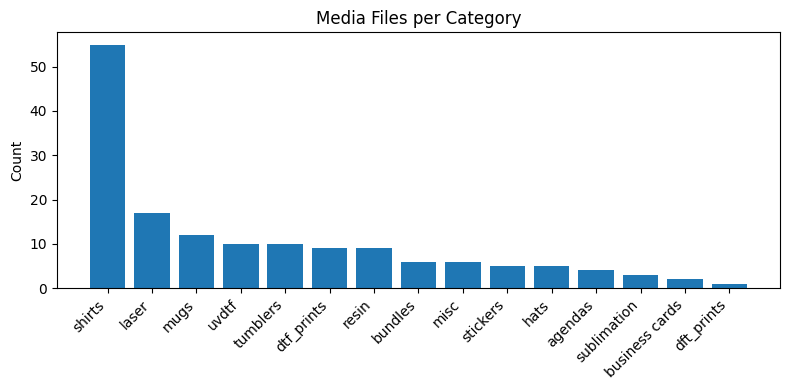

```
=== Media Files by Type ===
```

|  | file_type | count |
| --- | --- | --- |
| 0 | image | 137 |
| 1 | video | 17 |

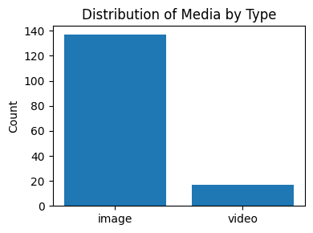

```python
# 1) Connect and load data
conn = connect_to_postgres()
df_media_files = pd.read_sql("SELECT * FROM media.media_files;", conn)
df_categories  = pd.read_sql("SELECT * FROM media.product_category;", conn)
df_labels      = pd.read_sql("SELECT * FROM media.media_labels;", conn)
conn.close()

# 2) Display samples
print("=== Media Files Sample ===")
display(df_media_files.head(10))
print("=== Categories ===")
display(df_categories)
print("=== Media Labels Sample ===")
display(df_labels.head(10))

# 3) Count of media files per category
counts = (
    df_media_files
      .groupby('category_id')
      .media_id.count()
      .reset_index(name='file_count')
      .merge(df_categories[['category_id','category_name']], on='category_id')
      .sort_values('file_count', ascending=False)
)
print("=== Media Files Count per Category ===")
display(counts)

# 4) Bar chart: Media files per category
plt.figure(figsize=(8,4))
plt.bar(counts['category_name'], counts['file_count'])
plt.xticks(rotation=45, ha='right')
plt.title("Media Files per Category")
plt.ylabel("Count")
plt.tight_layout()
plt.show()

# 5) Distribution by file type
type_counts = df_media_files['file_type'].value_counts().reset_index()
type_counts.columns = ['file_type', 'count']
print("=== Media Files by Type ===")
display(type_counts)

plt.figure(figsize=(4,3))
plt.bar(type_counts['file_type'], type_counts['count'])
plt.title("Distribution of Media by Type")
plt.ylabel("Count")
plt.tight_layout()
plt.show()
```

The exploratory data analysis (EDA) reveals a successful and structured ingestion of the media dataset into PostgreSQL. The bar chart titled "Media Files per Category" shows that most media files fall under the "shirts" category, followed by "laser", "mugs", and others like "uvdtf" and "tumblers", indicating class imbalance that may affect model training. Additionally, the "Distribution of Media by Type" chart confirms that the dataset is predominantly composed of images (137) compared to videos (17), suggesting the model should prioritize image classification. These insights confirm that the metadata ingestion process was executed correctly, all categories are properly registered, and the pipeline is ready to transition into the next phase of model development.

## Model Development

```python
# Phase 2: Setup for Model Development


# Reconnect to PostgreSQL
def connect_to_postgres():
    import getpass
    conn = psycopg2.connect(
        host="4.tcp.ngrok.io",        # e.g., "2.tcp.ngrok.io"
        port=11218,                   # e.g., 18083
        dbname="artiszen_db",
        user= input("Enter DB user: "),
        password= getpass.getpass("Enter DB password: ")
    )
    return conn

# Set base directory (same as Phase 1)
base_dir = "/content/drive/MyDrive/DL/artiszen_media"

# Load media metadata
conn = connect_to_postgres()
df_media_files = pd.read_sql("SELECT * FROM media.media_files WHERE file_type = 'image';", conn)
conn.close()

print("✅ df_media_files loaded:", df_media_files.shape)
print("Sample file path:", df_media_files.iloc[0]['file_path'])


# Ensure full reproducibility by fixing all random seeds
def seed_everything(seed: int = 42):
    os.environ['PYTHONHASHSEED'] = str(seed)
    random.seed(seed)
    np.random.seed(seed)
    torch.manual_seed(seed)
    torch.cuda.manual_seed_all(seed)
    torch.backends.cudnn.deterministic = True
    torch.backends.cudnn.benchmark = False

# Call once at the very start
seed_everything(42)
```

```
✅ df_media_files loaded: (137, 6)
Sample file path: artiszen_dataset_images/mugs/MG2301IMGIflintstones12ozBLK.jpg
```

### Image Integrity Check: Validating Image Files from Database

Before feeding images into the model, it's essential to ensure that each file path listed in the database:

- Exists on disk
- Can be successfully read using either cv2 or PIL
- Is not corrupt, unreadable, or mislabeled (e.g., video mistakenly labeled as image)

This code performs the following checks:

- Filters only image files (file_type = 'image')
- Attempts to load each image using OpenCV (cv2.imread())
- If OpenCV fails, it tries PIL (Image.open()) as a fallback.
- If both fail, the path is considered corrupt and added to a list for review.

The script outputs:

- Total number of problematic image files

This ensures that all image paths in the dataset are readable and ready for training.

```python
# Confirm File Existence before Loading

# Verify the image file path is valid and the file physically exists in the local file system.
missing_files = []

for _, row in df_media_files.iterrows():
    full_path = os.path.join(base_dir, row['file_path'])
    if not os.path.exists(full_path):
        missing_files.append(full_path)

print(f"❌ Missing files: {len(missing_files)}")
for path in missing_files[:5]:
    print(path)

if missing_files:
    raise FileNotFoundError(f"{len(missing_files)} image(s) missing; aborting pipeline.")
```

```
❌ Missing files: 0
```

```python
corrupt_files = []

for i, row in df_media_files.iterrows():
    if row['file_type'] != 'image':
        continue  # Skip non-image files

    img_path = os.path.join(base_dir, row['file_path'])

    try:
        img = cv2.imread(img_path)
        if img is None:
            raise ValueError("OpenCV failed")
        _ = cv2.cvtColor(img, cv2.COLOR_BGR2RGB)
    except:
        try:
            img = Image.open(img_path).convert("RGB")
        except:
            corrupt_files.append(img_path)

print(f"🧨 Total problematic images: {len(corrupt_files)}")
for path in corrupt_files[:5]:
    print("❌", path)
```

```
🧨 Total problematic images: 0
```

### Normalize and Analyze Image Properties

Before batching or augmenting, it's important to analyze image characteristics:

- resolution and aspect ratios

```python
from PIL import Image

sizes = []
for _, row in df_media_files.iterrows():
    if row['file_type'] != 'image':
        continue
    path = os.path.join(base_dir, row['file_path'])
    try:
        with Image.open(path) as img:
            sizes.append(img.size)
    except:
        continue

# Analyze
import collections
size_counts = collections.Counter(sizes)
print("🖼️ Top 5 image resolutions:")
print(size_counts.most_common(5))
```

```
🖼️ Top 5 image resolutions:
[((4000, 3000), 39), ((4000, 2252), 25), ((3000, 4000), 4), ((2252, 4000), 2), ((2249, 2997), 2)]
```

Based on the resolution analysis, the dataset consists of large, high-resolution images with significant variability in dimensions and orientation (landscape and portrait). To ensure consistency and improve model performance, it is recommended to standardize all inputs by resizing the images to a common resolution.

## 📌 Scope Clarification: Images vs Videos

This project currently focuses on **image classification** using high-resolution product photos from Artiszen Crafts. The pipeline will:

- Load and preprocess only media files with `file_type = 'image'`
- Apply normalization and data augmentation to image data
- Train and evaluate a CNN-based model for **static image recognition**

Although the dataset includes video files, **video classification is out of scope for this phase** and will be considered in a future enhancement. Potential directions include:

- Frame extraction for use in the image classifier
- Full video classification using architectures like I3D or TimeSformer
- Auto-thumbnailing or preview generation for cataloging

To avoid errors, all preprocessing and modeling code will **exclude video files** for now.

### Summary: Media File Type Handling

| Step | Applies to Images | Applies to Videos |
| --- | --- | --- |
| Resize | ✅ | ❌ |
| Normalize | ✅ | ❌ |
| Augmentation (Flip, Crop) | ✅ | ❌ |
| Torch Dataset prep | ✅ | ❌ |
| Video preprocessing | ❌ | 🔜 Planned |

### Data Augmentation and Preprocessing

This step prepares the images for training by:

- Standardizing input shape (e.g., resizing to 224×224)
- Applying augmentation to increase dataset variability and improve model generalization
- Normalizing pixel values to match the expected input range of pretrained CNNs (e.g., mean/std of ImageNet)

```python
train_transform = A.Compose([
    A.Resize(224, 224),
    A.HorizontalFlip(p=0.5),
    A.RandomBrightnessContrast(p=0.5),
    A.Rotate(limit=30, p=0.5),
    A.Affine(scale=(0.9, 1.1), translate_percent=0.05, rotate=(-15, 15), p=0.5),
    A.Normalize(mean=(0.485, 0.456, 0.406), std=(0.229, 0.224, 0.225)),
    ToTensorV2()
])

val_transform = A.Compose([
    A.Resize(224, 224),
    A.Normalize(mean=(0.485,0.456,0.406), std=(0.229,0.224,0.225)),
    ToTensorV2()
])
```

### Dataset Split Strategy

In this step, we split the image dataset into training, validation, and test sets using a stratified approach to maintain class balance.

Steps Performed:

1. Filter Images Only
- Select only media entries where file_type = 'image'.
2. Initial Stratified Split (70/30)
- The dataset is split into:
  - 70% training
  - 30% temporary (to later split into validation and test)

    The split is stratified by category_id to preserve class distributions.
3. Filter Out Rare Classes

Any class with fewer than 2 images in the temporary set is removed to avoid stratification errors.

4. Secondary Stratified Split (15/15)

The temporary set is split equally into: * 15% validation * 15% test

```
Again, using stratification to maintain balance.
```

5. Result Summary

The sizes of each subset are printed to confirm the split.

**Final Counts:**

- Training set: 95 samples
- Validation set: 18 samples
- Test set: 18 samples

```python
# Step 1: Filter only image files
df_images = df_media_files[df_media_files['file_type'] == 'image'].copy()

# Step 2: Stratified split (train 70%, temp 30%)
train_df, temp_df = train_test_split(
    df_images,
    test_size=0.30,
    stratify=df_images['category_id'],
    random_state=42
)

# Step 3: Filter out classes with only one image in temp_df
valid_classes = temp_df['category_id'].value_counts()
valid_classes = valid_classes[valid_classes >= 2].index
temp_df_filtered = temp_df[temp_df['category_id'].isin(valid_classes)]

# Step 4: Stratified split of temp_df into validation (15%) and test (15%)
val_df, test_df = train_test_split(
    temp_df_filtered,
    test_size=0.50,  # 50% of 30% = 15%
    stratify=temp_df_filtered['category_id'],
    random_state=42
)

# Step 5: Print result summary
print("✅ Train size:", len(train_df))
print("✅ Validation size:", len(val_df))
print("✅ Test size:", len(test_df))
```

```
✅ Train size: 95
✅ Validation size: 18
✅ Test size: 18
```

### Create Custom Dataset Classes for PyTorch and DataLoaders

Responsibilities:

- Accepts a DataFrame (e.g., train_df) and loads images from file_path
- Converts each image to RGB format (via cv2 or PIL)
- Applies the train_transform augmentation pipeline
- Returns (image_tensor, label)

```python
class ArtiszenImageDataset(Dataset):
    def __init__(self, df, base_dir, transform=None, fallback_size=(224, 224)):
        self.df = df.reset_index(drop=True)
        self.base_dir = base_dir
        self.transform = transform
        self.fallback_size = fallback_size

    def __len__(self):
        return len(self.df)

    def __getitem__(self, idx):
        row = self.df.iloc[idx]
        img_path = os.path.join(self.base_dir, row['file_path'])

        # ❌ Skip if file is not an image
        if not img_path.lower().endswith((".jpg", ".jpeg", ".png", ".bmp", ".gif", ".webp")):
            raise FileNotFoundError(f"⚠️ Skipping non-image file: {img_path}")

        image = cv2.imread(img_path)
        if image is None:
            print(f"⚠️ Fallback: Could not read image at {img_path}")
            image = np.zeros((*self.fallback_size, 3), dtype=np.uint8)  # black image
        else:
            image = cv2.cvtColor(image, cv2.COLOR_BGR2RGB)

        if self.transform:
            image = self.transform(image=image)['image']

        label = row['category_id']
        return image, label
```

```python
# Data Loaders

# Step 6: Fit label encoder on training labels only
encoder = LabelEncoder()
encoder.fit(train_df['category_id'])

# Step 7: Transform all splits using the same encoder
train_df['category_id'] = encoder.transform(train_df['category_id'])
val_df['category_id']   = encoder.transform(val_df['category_id'])
test_df['category_id']  = encoder.transform(test_df['category_id'])

# Step 8: Confirm number of classes
num_classes = len(encoder.classes_)

# Step 9: Create datasets from the splits
#    – train uses random augmentations
#    – val & test use only resize + normalize
train_dataset = ArtiszenImageDataset(train_df, base_dir, transform=train_transform)
val_dataset   = ArtiszenImageDataset(val_df,   base_dir, transform=val_transform)
test_dataset  = ArtiszenImageDataset(test_df,  base_dir, transform=val_transform)

# Step 10: Create data loaders
#    – train loader shuffles with a fixed seed generator
#    – val/test loaders don’t shuffle so order is stable
g = torch.Generator().manual_seed(42)

train_loader = DataLoader(
    train_dataset,
    batch_size=32,
    shuffle=True,
    generator=g
)
val_loader = DataLoader(
    val_dataset,
    batch_size=32,
    shuffle=False
)
test_loader = DataLoader(
    test_dataset,
    batch_size=32,
    shuffle=False
)
```

In this step, we defined and initialized a custom ArtiszenImageDataset class to handle image loading and preprocessing from the DataFrame.

The custom class:

- Accepts a DataFrame (train_df, val_df, or test_df) with image paths and labels.
- Uses cv2.imread() to read images and converts them to RGB format.
- Applies the train_transform pipeline using Albumentations.
- Returns the image tensor and its associated label.

We then instantiated three dataset objects:

- train_dataset, val_dataset, and test_dataset, each with the appropriate DataFrame and transformation.

Using torch.utils.data.DataLoader, we created:

- train_loader with batch size of 32 and shuffling enabled.
- val_loader and test_loader with batch size of 32 and no shuffling.

This setup enables efficient batch processing during training and evaluation, while also ensuring consistent data transformation and label pairing.

```python
# Test train_loader batch output
for imgs, labels in train_loader:
    print("✅ Train batch shape:", imgs.shape)
    print("🟧 Train labels:", labels)
    break

# Test val_loader batch output
for imgs, labels in val_loader:
    print("✅ Validation batch shape:", imgs.shape)
    print("🟧 Validation labels:", labels)
    break

# Test test_loader batch output
for imgs, labels in test_loader:
    print("✅ Test batch shape:", imgs.shape)
    print("🟧 Test labels:", labels)
    break
```

```
✅ Train batch shape: torch.Size([32, 3, 224, 224])
🟧 Train labels: tensor([ 6,  9, 12,  3,  9,  9,  7,  9,  9,  9, 12,  1, 12,  9,  9,  6,  9, 11,
         2,  5,  9,  5,  5,  9,  3,  5,  3, 10,  9,  0,  9,  1])
✅ Validation batch shape: torch.Size([18, 3, 224, 224])
🟧 Validation labels: tensor([13,  3,  6,  1,  9,  9,  5,  9,  9,  5,  8,  9,  5, 13,  9,  9, 10,  9])
✅ Test batch shape: torch.Size([18, 3, 224, 224])
🟧 Test labels: tensor([10,  6,  9,  9,  1,  3,  9,  9,  8, 13,  9,  5,  9,  9,  9,  3,  9,  5])
```

**Batch Loading Verification Summary**

This test confirms that our DataLoader objects for the training, validation, and test sets are correctly configured and functional. The printed outputs validate:

- Correct batch dimensions:
  - All batches return tensors in the shape [batch_size, 3, 224, 224], which matches the expected RGB format and resized dimensions.
  - For example, the train batch has a shape of [32, 3, 224, 224], meaning 32 RGB images of size 224×224.
- Label integrity:
  - Each image in the batch is associated with a valid category ID from the media.product_category table.
  - Labels are stored as integer tensors and match the size of their respective batches.
- Successful stratified split:
  - Training, validation, and test datasets are loaded independently with preserved category distribution.

This output confirms that the dataset is properly preprocessed and ready for CNN model training.

### CNN model training

#### 1. PyTorch CNN Model using ResNet18

This section implements a CNN image classifier using PyTorch with a pretrained ResNet18 model.

- All convolutional layers are frozen.
- Only the final fully connected layer is fine-tuned.
- CrossEntropyLoss is used for multiclass classification.

```python
# Load pretrained model
model = resnet18(pretrained=True)

# Freeze all layers (optional)
for param in model.parameters():
    param.requires_grad = False

# Replace the classifier head
num_classes = len(encoder.classes_)
model.fc = nn.Linear(model.fc.in_features, num_classes)
```

```python
model.fc = nn.Linear(model.fc.in_features, num_classes)

print("Unique category IDs:", train_df['category_id'].unique())
print("Max category ID:", train_df['category_id'].max())
print("Num classes:", len(train_df['category_id'].unique()))
```

```
Unique category IDs: [12 13 10  9  4  5  8  6  3  7  1  2 11  0]
Max category ID: 13
Num classes: 14
```

```python
num_classes = len(df_media_files['category_id'].unique())
```

```python
# Move model to device (GPU if available)
device = torch.device("cuda" if torch.cuda.is_available() else "cpu")
model.to(device)

# Define loss function and optimizer
criterion = nn.CrossEntropyLoss()
optimizer = optim.Adam(model.fc.parameters(), lr=0.001)  # Only training the classifier head

# Training loop
num_epochs = 50
for epoch in range(num_epochs):
    model.train()
    running_loss = 0.0
    all_preds, all_labels = [], []

    for images, labels in train_loader:
        images = images.to(device)
        labels = labels.to(device)

        optimizer.zero_grad()
        outputs = model(images)
        loss = criterion(outputs, labels)
        loss.backward()
        optimizer.step()

        running_loss += loss.item()
        all_preds.extend(torch.argmax(outputs, dim=1).cpu().numpy())
        all_labels.extend(labels.cpu().numpy())

    acc = accuracy_score(all_labels, all_preds)
    print(f"Epoch [{epoch+1}/{num_epochs}] - Loss: {running_loss:.4f} - Train Accuracy: {acc:.4f}")
```

```
Epoch [1/50] - Loss: 8.0196 - Train Accuracy: 0.0947
Epoch [2/50] - Loss: 6.6480 - Train Accuracy: 0.3895
Epoch [3/50] - Loss: 6.2731 - Train Accuracy: 0.3895
Epoch [4/50] - Loss: 6.1012 - Train Accuracy: 0.3895
Epoch [5/50] - Loss: 5.7023 - Train Accuracy: 0.3789
Epoch [6/50] - Loss: 5.3910 - Train Accuracy: 0.4421
Epoch [7/50] - Loss: 5.1585 - Train Accuracy: 0.4947
Epoch [8/50] - Loss: 4.6779 - Train Accuracy: 0.5158
Epoch [9/50] - Loss: 4.4031 - Train Accuracy: 0.4737
Epoch [10/50] - Loss: 4.1637 - Train Accuracy: 0.4947
Epoch [11/50] - Loss: 4.1705 - Train Accuracy: 0.5053
Epoch [12/50] - Loss: 3.8192 - Train Accuracy: 0.5789
Epoch [13/50] - Loss: 3.6142 - Train Accuracy: 0.6000
Epoch [14/50] - Loss: 3.3693 - Train Accuracy: 0.7053
Epoch [15/50] - Loss: 3.3207 - Train Accuracy: 0.7158
Epoch [16/50] - Loss: 2.9542 - Train Accuracy: 0.7368
Epoch [17/50] - Loss: 2.8934 - Train Accuracy: 0.7263
Epoch [18/50] - Loss: 2.8260 - Train Accuracy: 0.8211
Epoch [19/50] - Loss: 2.5318 - Train Accuracy: 0.7789
Epoch [20/50] - Loss: 2.5559 - Train Accuracy: 0.8211
Epoch [21/50] - Loss: 2.2529 - Train Accuracy: 0.9158
Epoch [22/50] - Loss: 2.2186 - Train Accuracy: 0.9263
Epoch [23/50] - Loss: 2.0144 - Train Accuracy: 0.8842
Epoch [24/50] - Loss: 2.1004 - Train Accuracy: 0.8316
Epoch [25/50] - Loss: 2.0657 - Train Accuracy: 0.8526
Epoch [26/50] - Loss: 1.8693 - Train Accuracy: 0.8842
Epoch [27/50] - Loss: 1.7492 - Train Accuracy: 0.9158
Epoch [28/50] - Loss: 1.7816 - Train Accuracy: 0.9263
Epoch [29/50] - Loss: 1.7237 - Train Accuracy: 0.8947
Epoch [30/50] - Loss: 1.6201 - Train Accuracy: 0.9368
Epoch [31/50] - Loss: 1.6029 - Train Accuracy: 0.9053
Epoch [32/50] - Loss: 1.4315 - Train Accuracy: 0.9579
Epoch [33/50] - Loss: 1.4318 - Train Accuracy: 0.9474
Epoch [34/50] - Loss: 1.4348 - Train Accuracy: 0.9474
Epoch [35/50] - Loss: 1.1751 - Train Accuracy: 0.9474
Epoch [36/50] - Loss: 1.2470 - Train Accuracy: 0.9684
Epoch [37/50] - Loss: 1.1359 - Train Accuracy: 0.9789
Epoch [38/50] - Loss: 1.2200 - Train Accuracy: 0.9895
Epoch [39/50] - Loss: 1.0606 - Train Accuracy: 0.9895
Epoch [40/50] - Loss: 1.0176 - Train Accuracy: 0.9789
Epoch [41/50] - Loss: 1.2289 - Train Accuracy: 0.9579
Epoch [42/50] - Loss: 0.9895 - Train Accuracy: 0.9684
Epoch [43/50] - Loss: 1.0499 - Train Accuracy: 0.9684
Epoch [44/50] - Loss: 0.9508 - Train Accuracy: 1.0000
Epoch [45/50] - Loss: 0.8993 - Train Accuracy: 0.9895
Epoch [46/50] - Loss: 0.8489 - Train Accuracy: 0.9895
Epoch [47/50] - Loss: 0.9469 - Train Accuracy: 0.9789
Epoch [48/50] - Loss: 0.8619 - Train Accuracy: 0.9789
Epoch [49/50] - Loss: 0.7910 - Train Accuracy: 0.9684
Epoch [50/50] - Loss: 0.9531 - Train Accuracy: 0.9789
```

```python
# Evaluate on validation set
model.eval()
all_preds, all_labels = [], []
with torch.no_grad():
    for images, labels in val_loader:
        images, labels = images.to(device), labels.to(device)
        outputs = model(images)
        all_preds.extend(torch.argmax(outputs, dim=1).cpu().numpy())
        all_labels.extend(labels.cpu().numpy())

val_acc = accuracy_score(all_labels, all_preds)
print(f"✅ PyTorch Validation Accuracy: {val_acc:.4f}")
```

```
✅ PyTorch Validation Accuracy: 0.7778
```

```python
# Evaluate on test set
model.eval()
all_preds, all_labels = [], []

with torch.no_grad():
    for images, labels in test_loader:
        images, labels = images.to(device), labels.to(device)
        outputs = model(images)
        preds = torch.argmax(outputs, dim=1)
        all_preds.extend(preds.cpu().numpy())
        all_labels.extend(labels.cpu().numpy())

test_acc = accuracy_score(all_labels, all_preds)
print(f"✅ PyTorch Test Accuracy:       {test_acc:.4f}")
```

```
✅ PyTorch Test Accuracy:       0.6111
```

### Run Evaluation on Validation and Test Set Using PyTorch

```
📋 Classification Report for Validation Set:

              precision    recall  f1-score   support

           0       0.00      0.00      0.00         0
           1       1.00      1.00      1.00         1
           2       0.00      0.00      0.00         0
           3       0.00      0.00      0.00         1
           4       0.00      0.00      0.00         0
           5       0.60      1.00      0.75         3
           6       0.00      0.00      0.00         1
           7       0.00      0.00      0.00         0
           8       1.00      1.00      1.00         1
           9       0.80      1.00      0.89         8
          10       0.00      0.00      0.00         1
          11       0.00      0.00      0.00         0
          12       0.00      0.00      0.00         0
          13       1.00      0.50      0.67         2

    accuracy                           0.78        18
   macro avg       0.31      0.32      0.31        18
weighted avg       0.68      0.78      0.71        18
```

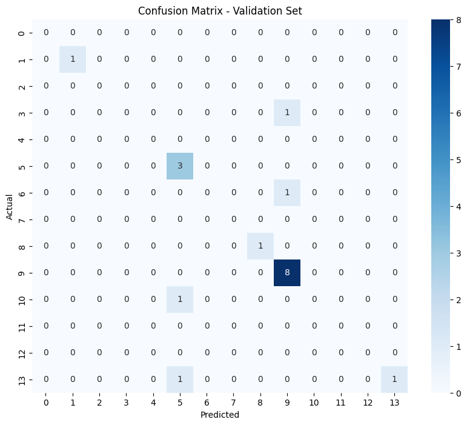

```
📋 Classification Report for Test Set:

              precision    recall  f1-score   support

           0       0.00      0.00      0.00         0
           1       0.00      0.00      0.00         1
           2       0.00      0.00      0.00         0
           3       0.00      0.00      0.00         2
           4       0.00      0.00      0.00         0
           5       0.33      0.50      0.40         2
           6       0.00      0.00      0.00         1
           7       0.00      0.00      0.00         0
           8       1.00      1.00      1.00         1
           9       0.90      1.00      0.95         9
          10       0.00      0.00      0.00         1
          11       0.00      0.00      0.00         0
          12       0.00      0.00      0.00         0
          13       0.00      0.00      0.00         1

    accuracy                           0.61        18
   macro avg       0.16      0.18      0.17        18
weighted avg       0.54      0.61      0.57        18
```

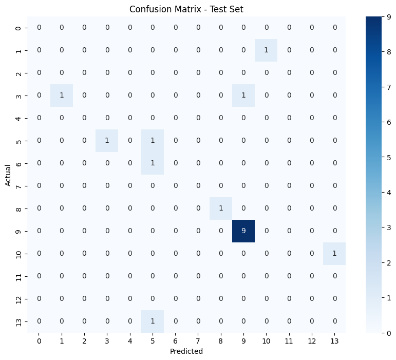

```python
#PyTorch

# Build class name list from label encoder
class_names = encoder.classes_.astype(str).tolist()
all_class_indices = list(range(len(class_names)))  # Ensure all expected class indices are included

# Print classification report
def print_classification_report(y_true, y_pred, class_names, labels, dataset_name="Validation"):
    print(f"\n📋 Classification Report for {dataset_name} Set:\n")
    report = classification_report(y_true, y_pred, labels=labels, target_names=class_names)
    print(report)

# Confusion matrix plot
def plot_confusion_matrix(y_true, y_pred, class_names, labels, dataset_name="Validation"):
    cm = confusion_matrix(y_true, y_pred, labels=labels)
    plt.figure(figsize=(10, 8))
    sns.heatmap(cm, annot=True, fmt='d', cmap='Blues',
                xticklabels=class_names,
                yticklabels=class_names)
    plt.xlabel("Predicted")
    plt.ylabel("Actual")
    plt.title(f"Confusion Matrix - {dataset_name} Set")
    plt.show()

# Model evaluation
def evaluate_model(model, data_loader, device):
    model.eval()
    model.to(device)

    all_preds = []
    all_labels = []

    with torch.no_grad():
        for images, labels in data_loader:
            images = images.to(device)
            labels = labels.to(device)
            outputs = model(images)
            preds = torch.argmax(outputs, dim=1)
            all_preds.extend(preds.cpu().numpy())
            all_labels.extend(labels.cpu().numpy())

    return all_labels, all_preds

# Evaluation on Validation Set
val_true, val_pred = evaluate_model(model, val_loader, device='cuda' if torch.cuda.is_available() else 'cpu')
print_classification_report(val_true, val_pred, class_names, all_class_indices, dataset_name="Validation")
plot_confusion_matrix(val_true, val_pred, class_names, all_class_indices, dataset_name="Validation")

# Evaluation on Test Set
test_true, test_pred = evaluate_model(model, test_loader, device='cuda' if torch.cuda.is_available() else 'cpu')
print_classification_report(test_true, test_pred, class_names, all_class_indices, dataset_name="Test")
plot_confusion_matrix(test_true, test_pred, class_names, all_class_indices, dataset_name="Test")
```

### Evaluation Summary for PyTorch Model (ResNet18)

The confusion matrices and classification reports shown above correspond to the evaluation of the PyTorch model on the **Validation Set** and **Test Set**.

### 2. TensorFlow CNN Model using ResNet50

This section uses TensorFlow/Keras with a pretrained ResNet50 base:

- The convolutional base is frozen (ImageNet-trained).
- A custom classification head is added.
- Categorical cross-entropy is used for multiclass classification.

```python
tf.random.set_seed(42)
tf.config.experimental.enable_op_determinism()

# Define number of output classes
num_classes = df_media_files['category_id'].nunique()

# Load pretrained base model
base_model = ResNet50(
    weights='imagenet',
    include_top=False,
    input_shape=(224, 224, 3)
)

# Optionally freeze the base model for transfer learning
base_model.trainable = False

# Build full model
model_tf = models.Sequential([
    base_model,
    layers.GlobalAveragePooling2D(),
    layers.Dense(256, activation='relu'),
    layers.Dense(num_classes, activation='softmax')
])

# Compile the model
model_tf.compile(
    optimizer=optimizers.Adam(),
    loss='sparse_categorical_crossentropy',
    metrics=['accuracy']
)

# Optional: show model summary
model_tf.summary()
```

```
Model: "sequential_1"
```

```
┏━━━━━━━━━━━━━━━━━━━━━━━━━━━━━━━━━┳━━━━━━━━━━━━━━━━━━━━━━━━┳━━━━━━━━━━━━━━━┓
┃ Layer (type)                    ┃ Output Shape           ┃       Param # ┃
┡━━━━━━━━━━━━━━━━━━━━━━━━━━━━━━━━━╇━━━━━━━━━━━━━━━━━━━━━━━━╇━━━━━━━━━━━━━━━┩
│ resnet50 (Functional)           │ (None, 7, 7, 2048)     │    23,587,712 │
├─────────────────────────────────┼────────────────────────┼───────────────┤
│ global_average_pooling2d_1      │ (None, 2048)           │             0 │
│ (GlobalAveragePooling2D)        │                        │               │
├─────────────────────────────────┼────────────────────────┼───────────────┤
│ dense_2 (Dense)                 │ (None, 256)            │       524,544 │
├─────────────────────────────────┼────────────────────────┼───────────────┤
│ dense_3 (Dense)                 │ (None, 14)             │         3,598 │
└─────────────────────────────────┴────────────────────────┴───────────────┘
```

```
 Total params: 24,115,854 (91.99 MB)
```

```
 Trainable params: 528,142 (2.01 MB)
```

```
 Non-trainable params: 23,587,712 (89.98 MB)
```

**Convolutional Neural Networks (CNNs)** are a foundational architecture in deep learning for image classification tasks, leveraging spatial hierarchies in visual data through convolutional layers, pooling, and nonlinear activations.

The Sequential model consists of four main components:

1. **ResNet50 Base (Functional)**
   - **Output shape:** `(None, 7, 7, 2048)`
   - **Parameters:** 23,587,712 (all frozen)  
     This block retains all of ResNet50’s pretrained ImageNet weights, producing rich 7×7 spatial feature maps with 2048 channels.
2. **GlobalAveragePooling2D**
   - **Output shape:** `(None, 2048)`
   - **Parameters:** 0  
     This layer collapses each 7×7 feature map into a single summary statistic per channel, reducing the tensor to a flat 2048-dimensional vector.
3. **Dense (256 units, ReLU)**
   - **Output shape:** `(None, 256)`
   - **Parameters:** 524,544 (trainable)  
     This fully connected layer introduces a learnable projection from the 2048 features down to 256 hidden units, with ReLU nonlinearity for added expressiveness.
4. **Dense (num_classes, softmax)**
   - **Output shape:** `(None, 14)`
   - **Parameters:** 3,598 (trainable)  
     The final classification head maps the 256-dimensional hidden vector into 14 class probabilities via a softmax activation.
- **Total parameters:** 24,115,854
- **Trainable parameters:** 528,142 (≈ 2.2%)
- **Non-trainable parameters:** 23,587,712 (≈ 97.8%)

By freezing the massive ResNet50 backbone and training only ~2 % of the weights in the new head, we keep the model lightweight to train while still leveraging powerful pretrained features. This results in fast convergence and efficient use of limited data.

```python
# TENSORFLOW

def load_and_preprocess_image(path, label):
    image = tf.io.read_file(path)
    image = tf.image.decode_jpeg(image, channels=3)
    image = tf.image.resize(image, [224, 224]) / 255.0
    return image, label

# Step 1: Extract image paths and labels
train_paths = train_df['file_path'].apply(lambda x: os.path.join(base_dir, x)).tolist()
val_paths   = val_df['file_path'].apply(lambda x: os.path.join(base_dir, x)).tolist()

train_labels = train_df['category_id'].astype(np.int32).tolist()
val_labels   = val_df['category_id'].astype(np.int32).tolist()

# Step 2: Create TensorFlow datasets
train_tf_dataset = tf.data.Dataset.from_tensor_slices((train_paths, train_labels))
val_tf_dataset   = tf.data.Dataset.from_tensor_slices((val_paths, val_labels))

# Step 3: Apply image loading + preprocessing
train_tf_dataset = (
    train_tf_dataset
      .map(load_and_preprocess_image)
      .shuffle(buffer_size=100, seed=42)   # ← now deterministic
      .batch(32)
      .prefetch(tf.data.AUTOTUNE)
)

val_tf_dataset   = val_tf_dataset.map(load_and_preprocess_image).batch(32).prefetch(tf.data.AUTOTUNE)

# Step 4: Extract test image paths and labels
test_paths  = test_df['file_path'].apply(lambda x: os.path.join(base_dir, x)).tolist()
test_labels = test_df['category_id'].astype(np.int32).tolist()

# Step 5: Create TensorFlow test dataset
test_tf_dataset = (
    tf.data.Dataset.from_tensor_slices((test_paths, test_labels))
      .map(load_and_preprocess_image)
      .batch(32)
      .prefetch(tf.data.AUTOTUNE)
)
```

```python
history = model_tf.fit(train_tf_dataset, validation_data=val_tf_dataset, epochs=50)
```

```
3/3 ━━━━━━━━━━━━━━━━━━━━ 39s 9s/step - accuracy: 0.2007 - loss: 2.5783 - val_accuracy: 0.4444 - val_loss: 2.0330
3/3 ━━━━━━━━━━━━━━━━━━━━ 28s 8s/step - accuracy: 0.4018 - loss: 2.2425 - val_accuracy: 0.5556 - val_loss: 1.9432
3/3 ━━━━━━━━━━━━━━━━━━━━ 27s 8s/step - accuracy: 0.4081 - loss: 2.1572 - val_accuracy: 0.5556 - val_loss: 1.9697
3/3 ━━━━━━━━━━━━━━━━━━━━ 27s 8s/step - accuracy: 0.4057 - loss: 2.1570 - val_accuracy: 0.4444 - val_loss: 1.9391
3/3 ━━━━━━━━━━━━━━━━━━━━ 42s 8s/step - accuracy: 0.4135 - loss: 2.0607 - val_accuracy: 0.4444 - val_loss: 1.9496
3/3 ━━━━━━━━━━━━━━━━━━━━ 27s 8s/step - accuracy: 0.3940 - loss: 2.0486 - val_accuracy: 0.4444 - val_loss: 1.9093
3/3 ━━━━━━━━━━━━━━━━━━━━ 32s 10s/step - accuracy: 0.4176 - loss: 1.9853 - val_accuracy: 0.5000 - val_loss: 1.9131
3/3 ━━━━━━━━━━━━━━━━━━━━ 28s 8s/step - accuracy: 0.4384 - loss: 1.9552 - val_accuracy: 0.4444 - val_loss: 1.8762
3/3 ━━━━━━━━━━━━━━━━━━━━ 40s 8s/step - accuracy: 0.4189 - loss: 1.9365 - val_accuracy: 0.4444 - val_loss: 1.8707
3/3 ━━━━━━━━━━━━━━━━━━━━ 32s 10s/step - accuracy: 0.4332 - loss: 1.9124 - val_accuracy: 0.4444 - val_loss: 1.8711
3/3 ━━━━━━━━━━━━━━━━━━━━ 41s 10s/step - accuracy: 0.4865 - loss: 1.7424 - val_accuracy: 0.4444 - val_loss: 1.8878
3/3 ━━━━━━━━━━━━━━━━━━━━ 41s 10s/step - accuracy: 0.4463 - loss: 1.8657 - val_accuracy: 0.4444 - val_loss: 1.9109
3/3 ━━━━━━━━━━━━━━━━━━━━ 29s 8s/step - accuracy: 0.3863 - loss: 1.8915 - val_accuracy: 0.5000 - val_loss: 1.9113
3/3 ━━━━━━━━━━━━━━━━━━━━ 27s 8s/step - accuracy: 0.4529 - loss: 1.8418 - val_accuracy: 0.4444 - val_loss: 1.9033
3/3 ━━━━━━━━━━━━━━━━━━━━ 28s 8s/step - accuracy: 0.4072 - loss: 1.8996 - val_accuracy: 0.4444 - val_loss: 1.9075
3/3 ━━━━━━━━━━━━━━━━━━━━ 27s 8s/step - accuracy: 0.4593 - loss: 1.7750 - val_accuracy: 0.4444 - val_loss: 1.8956
3/3 ━━━━━━━━━━━━━━━━━━━━ 32s 10s/step - accuracy: 0.4593 - loss: 1.7489 - val_accuracy: 0.5000 - val_loss: 1.9028
3/3 ━━━━━━━━━━━━━━━━━━━━ 28s 8s/step - accuracy: 0.4281 - loss: 1.7720 - val_accuracy: 0.5000 - val_loss: 1.8978
3/3 ━━━━━━━━━━━━━━━━━━━━ 28s 8s/step - accuracy: 0.4671 - loss: 1.6903 - val_accuracy: 0.4444 - val_loss: 1.9255
3/3 ━━━━━━━━━━━━━━━━━━━━ 32s 10s/step - accuracy: 0.4828 - loss: 1.6496 - val_accuracy: 0.4444 - val_loss: 1.9367
3/3 ━━━━━━━━━━━━━━━━━━━━ 41s 10s/step - accuracy: 0.4919 - loss: 1.6611 - val_accuracy: 0.5000 - val_loss: 1.9517
3/3 ━━━━━━━━━━━━━━━━━━━━ 27s 8s/step - accuracy: 0.4998 - loss: 1.6509 - val_accuracy: 0.5000 - val_loss: 1.9520
3/3 ━━━━━━━━━━━━━━━━━━━━ 32s 10s/step - accuracy: 0.4437 - loss: 1.7014 - val_accuracy: 0.4444 - val_loss: 1.9643
3/3 ━━━━━━━━━━━━━━━━━━━━ 36s 8s/step - accuracy: 0.4541 - loss: 1.6283 - val_accuracy: 0.4444 - val_loss: 1.9556
3/3 ━━━━━━━━━━━━━━━━━━━━ 27s 8s/step - accuracy: 0.3968 - loss: 1.7200 - val_accuracy: 0.5000 - val_loss: 1.9483
3/3 ━━━━━━━━━━━━━━━━━━━━ 26s 8s/step - accuracy: 0.4425 - loss: 1.6760 - val_accuracy: 0.5000 - val_loss: 1.9512
3/3 ━━━━━━━━━━━━━━━━━━━━ 48s 11s/step - accuracy: 0.4816 - loss: 1.5742 - val_accuracy: 0.4444 - val_loss: 1.9897
3/3 ━━━━━━━━━━━━━━━━━━━━ 28s 8s/step - accuracy: 0.4152 - loss: 1.7099 - val_accuracy: 0.4444 - val_loss: 2.0171
3/3 ━━━━━━━━━━━━━━━━━━━━ 32s 10s/step - accuracy: 0.4425 - loss: 1.5996 - val_accuracy: 0.4444 - val_loss: 2.0194
3/3 ━━━━━━━━━━━━━━━━━━━━ 29s 8s/step - accuracy: 0.3669 - loss: 1.7325 - val_accuracy: 0.4444 - val_loss: 2.0172
3/3 ━━━━━━━━━━━━━━━━━━━━ 41s 8s/step - accuracy: 0.4384 - loss: 1.5623 - val_accuracy: 0.4444 - val_loss: 2.0091
3/3 ━━━━━━━━━━━━━━━━━━━━ 28s 8s/step - accuracy: 0.4464 - loss: 1.5977 - val_accuracy: 0.4444 - val_loss: 1.9982
3/3 ━━━━━━━━━━━━━━━━━━━━ 40s 8s/step - accuracy: 0.4817 - loss: 1.5617 - val_accuracy: 0.4444 - val_loss: 2.0030
3/3 ━━━━━━━━━━━━━━━━━━━━ 32s 10s/step - accuracy: 0.4999 - loss: 1.4963 - val_accuracy: 0.4444 - val_loss: 2.0259
3/3 ━━━━━━━━━━━━━━━━━━━━ 36s 8s/step - accuracy: 0.4685 - loss: 1.5027 - val_accuracy: 0.4444 - val_loss: 2.0612
3/3 ━━━━━━━━━━━━━━━━━━━━ 46s 10s/step - accuracy: 0.4687 - loss: 1.4987 - val_accuracy: 0.3889 - val_loss: 2.0647
3/3 ━━━━━━━━━━━━━━━━━━━━ 36s 8s/step - accuracy: 0.5052 - loss: 1.4540 - val_accuracy: 0.4444 - val_loss: 2.0487
3/3 ━━━━━━━━━━━━━━━━━━━━ 46s 11s/step - accuracy: 0.4609 - loss: 1.4732 - val_accuracy: 0.4444 - val_loss: 2.0677
3/3 ━━━━━━━━━━━━━━━━━━━━ 27s 8s/step - accuracy: 0.5142 - loss: 1.4065 - val_accuracy: 0.4444 - val_loss: 2.0625
3/3 ━━━━━━━━━━━━━━━━━━━━ 41s 8s/step - accuracy: 0.5300 - loss: 1.3800 - val_accuracy: 0.4444 - val_loss: 2.0516
3/3 ━━━━━━━━━━━━━━━━━━━━ 32s 10s/step - accuracy: 0.5183 - loss: 1.4256 - val_accuracy: 0.3889 - val_loss: 2.0613
3/3 ━━━━━━━━━━━━━━━━━━━━ 28s 8s/step - accuracy: 0.5183 - loss: 1.4302 - val_accuracy: 0.4444 - val_loss: 2.0830
3/3 ━━━━━━━━━━━━━━━━━━━━ 27s 8s/step - accuracy: 0.4661 - loss: 1.4003 - val_accuracy: 0.4444 - val_loss: 2.1111
3/3 ━━━━━━━━━━━━━━━━━━━━ 27s 8s/step - accuracy: 0.5442 - loss: 1.3906 - val_accuracy: 0.4444 - val_loss: 2.1136
3/3 ━━━━━━━━━━━━━━━━━━━━ 27s 8s/step - accuracy: 0.5040 - loss: 1.4182 - val_accuracy: 0.3889 - val_loss: 2.1069
3/3 ━━━━━━━━━━━━━━━━━━━━ 46s 11s/step - accuracy: 0.5536 - loss: 1.3613 - val_accuracy: 0.4444 - val_loss: 2.1051
3/3 ━━━━━━━━━━━━━━━━━━━━ 41s 10s/step - accuracy: 0.5210 - loss: 1.3323 - val_accuracy: 0.4444 - val_loss: 2.1104
3/3 ━━━━━━━━━━━━━━━━━━━━ 27s 8s/step - accuracy: 0.5235 - loss: 1.3175 - val_accuracy: 0.4444 - val_loss: 2.1319
3/3 ━━━━━━━━━━━━━━━━━━━━ 32s 10s/step - accuracy: 0.5483 - loss: 1.2732 - val_accuracy: 0.4444 - val_loss: 2.1283
3/3 ━━━━━━━━━━━━━━━━━━━━ 27s 8s/step - accuracy: 0.5419 - loss: 1.3109 - val_accuracy: 0.4444 - val_loss: 2.1354
```

```python
# Evaluate on Train, Validation and Test Sets

# Evaluate on the Training Set
train_loss, train_acc = model_tf.evaluate(train_tf_dataset, verbose=0)
print(f"✅ TensorFlow Training Accuracy:   {train_acc:.4f}")

# Evaluate on the Validation Set
val_loss, val_acc = model_tf.evaluate(val_tf_dataset, verbose=0)
print(f"✅ TensorFlow Validation Accuracy: {val_acc:.4f}")

# Evaluate on the Test Set
test_loss, test_acc = model_tf.evaluate(test_tf_dataset, verbose=0)
print(f"✅ TensorFlow Test Accuracy:       {test_acc:.4f}")
```

```
✅ TensorFlow Training Accuracy:   0.5368
✅ TensorFlow Validation Accuracy: 0.4444
✅ TensorFlow Test Accuracy:       0.5556
```

[figure not shown]

```python
# 1) Extract the true labels from each dataset
train_true = np.concatenate([y.numpy() for x, y in train_tf_dataset], axis=0)
val_true   = np.concatenate([y.numpy() for x, y in val_tf_dataset],   axis=0)
test_true  = np.concatenate([y.numpy() for x, y in test_tf_dataset],  axis=0)

# 2) Get the model’s predictions for each split
train_pred = np.argmax(model_tf.predict(train_tf_dataset, verbose=0), axis=1)
val_pred   = np.argmax(model_tf.predict(val_tf_dataset,   verbose=0), axis=1)
test_pred  = np.argmax(model_tf.predict(test_tf_dataset,  verbose=0), axis=1)

# Make sure you have a list of human-readable class names:
# class_names = encoder.classes_.tolist()

# 3) Plot side-by-side confusion matrices
fig, axes = plt.subplots(1, 3, figsize=(18, 5), constrained_layout=True)
for ax, (name, y_true, y_pred) in zip(axes, [
    ("Train",      train_true, train_pred),
    ("Validation", val_true,   val_pred),
    ("Test",       test_true,  test_pred),
]):
    cm = confusion_matrix(y_true, y_pred)
    sns.heatmap(cm, annot=True, fmt='d', cmap='Blues',
                xticklabels=class_names, yticklabels=class_names,
                ax=ax)
    ax.set_title(f"Confusion Matrix – {name}")
    ax.set_xlabel("Predicted")
    ax.set_ylabel("Actual")

plt.show()
```

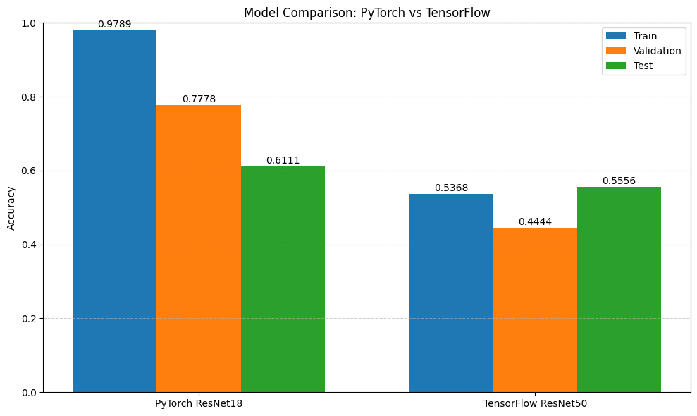

```python
# Model names
model_names = ['PyTorch ResNet18', 'TensorFlow ResNet50']

# Replace these with your real accuracy values
train_accuracies = [0.9789, 0.5368]   # e.g. PyTorch train acc, TensorFlow train acc
val_accuracies   = [0.7778, 0.4444]   # your validation accuracies
test_accuracies  = [0.6111, 0.5556]   # e.g. PyTorch test acc, TensorFlow test acc

# X-axis positions and bar width
x = np.arange(len(model_names))
width = 0.25

fig, ax = plt.subplots(figsize=(10, 6))
bar1 = ax.bar(x - width, train_accuracies, width, label='Train')
bar2 = ax.bar(x,         val_accuracies,   width, label='Validation')
bar3 = ax.bar(x + width, test_accuracies,  width, label='Test')

# Labels, title, and legend
ax.set_xticks(x)
ax.set_xticklabels(model_names)
ax.set_ylim(0, 1)
ax.set_ylabel('Accuracy')
ax.set_title('Model Comparison: PyTorch vs TensorFlow')
ax.legend()

# Annotate each bar with its height
for bar_group in (bar1, bar2, bar3):
    for bar in bar_group:
        height = bar.get_height()
        ax.annotate(f'{height:.4f}',
                    xy=(bar.get_x() + bar.get_width() / 2, height),
                    xytext=(0, 3),  # 3 points vertical offset
                    textcoords='offset points',
                    ha='center')

ax.grid(axis='y', linestyle='--', alpha=0.6)
plt.tight_layout()
plt.show()
```

**Interpretation**

- **PyTorch ResNet18**
  - **Train: 97.89% → Validation: 77.78% → Test: 61.11%**
  - The large drop from train to validation (−20.11 pp) and further to test (−16.67 pp) indicates notable overfitting. Despite memorizing the training set, it still achieves a solid 61% on unseen data, suggesting the learned features are useful but could benefit from stronger regularization.
- **TensorFlow ResNet50**
  - **Train: 53.68% → Validation: 44.44% → Test: 55.56%**
  - Overall low training and validation accuracy reveals underfitting: the frozen ResNet50 base plus lightweight head isn’t capturing enough signal. Interestingly, test accuracy (55.56%) surpasses validation, hinting at either random sampling variation or that the test split is easier for this model’s learned representations.

**Key Takeaways**

### Run Evaluation on the Train and Validation Sets Using TensorFlow

```python
# Get Predictions for Train and Validation Sets

def get_preds_and_labels_tf(dataset):
    all_preds, all_labels = [], []
    for images, labels in dataset:
        preds = model_tf.predict(images)
        predicted_classes = np.argmax(preds, axis=1)
        all_preds.extend(predicted_classes)
        all_labels.extend(labels.numpy())
    return np.array(all_labels), np.array(all_preds)

# Get predictions
train_true, train_preds_class = get_preds_and_labels_tf(train_tf_dataset)
val_true, val_preds_class     = get_preds_and_labels_tf(val_tf_dataset)
```

[output not shown]

```
1/1 ━━━━━━━━━━━━━━━━━━━━ 8s 8s/step
1/1 ━━━━━━━━━━━━━━━━━━━━ 6s 6s/step
```

[output not shown]

```
1/1 ━━━━━━━━━━━━━━━━━━━━ 7s 7s/step
1/1 ━━━━━━━━━━━━━━━━━━━━ 3s 3s/step
```

```python
# Classification Reports


# 1) Identify which labels actually appear in each split
train_labels = np.unique(train_true)
val_labels   = np.unique(val_true)

# 2) Map those back to human-readable names
train_target_names = [class_names[i] for i in train_labels]
val_target_names   = [class_names[i] for i in val_labels]

# 3) Print your TensorFlow classification reports
print("📋 Train Report (TensorFlow):")
print(classification_report(
    train_true,
    train_preds_class,
    labels=train_labels,
    target_names=train_target_names,
    zero_division=0
))

print("📋 Validation Report (TensorFlow):")
print(classification_report(
    val_true,
    val_preds_class,
    labels=val_labels,
    target_names=val_target_names,
    zero_division=0
))
```

```
📋 Train Report (TensorFlow):
              precision    recall  f1-score   support

           0       0.00      0.00      0.00         1
           1       1.00      0.25      0.40         4
           2       1.00      1.00      1.00         1
           3       0.00      0.00      0.00         6
           4       0.00      0.00      0.00         4
           5       0.89      0.67      0.76        12
           6       0.67      0.50      0.57         4
           7       0.67      0.50      0.57         4
           8       0.00      0.00      0.00         6
           9       0.47      0.97      0.63        37
          10       0.00      0.00      0.00         3
          11       1.00      0.50      0.67         2
          12       0.00      0.00      0.00         4
          13       0.00      0.00      0.00         7

    accuracy                           0.54        95
   macro avg       0.41      0.31      0.33        95
weighted avg       0.42      0.54      0.43        95

📋 Validation Report (TensorFlow):
              precision    recall  f1-score   support

           1       0.00      0.00      0.00         1
           3       0.00      0.00      0.00         1
           5       0.00      0.00      0.00         3
           6       0.00      0.00      0.00         1
           8       0.00      0.00      0.00         1
           9       0.50      1.00      0.67         8
          10       0.00      0.00      0.00         1
          13       0.00      0.00      0.00         2

   micro avg       0.47      0.44      0.46        18
   macro avg       0.06      0.12      0.08        18
weighted avg       0.22      0.44      0.30        18
```

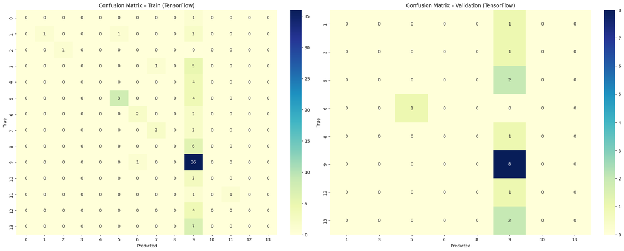

```python
# Confusion Matrices


# 4) Plot side‐by‐side confusion matrices
fig, axes = plt.subplots(1, 2, figsize=(20, 8), constrained_layout=True)

# — Train Confusion Matrix —
cm_train = confusion_matrix(train_true, train_preds_class, labels=train_labels)
sns.heatmap(
    cm_train, annot=True, fmt="d", cmap="YlGnBu",
    xticklabels=train_target_names,
    yticklabels=train_target_names,
    ax=axes[0]
)
axes[0].set_title("Confusion Matrix – Train (TensorFlow)")
axes[0].set_xlabel("Predicted")
axes[0].set_ylabel("True")

# — Validation Confusion Matrix —
cm_val = confusion_matrix(val_true, val_preds_class, labels=val_labels)
sns.heatmap(
    cm_val, annot=True, fmt="d", cmap="YlGnBu",
    xticklabels=val_target_names,
    yticklabels=val_target_names,
    ax=axes[1]
)
axes[1].set_title("Confusion Matrix – Validation (TensorFlow)")
axes[1].set_xlabel("Predicted")
axes[1].set_ylabel("True")

plt.show()
```

```python
print("Train set:", train_true.shape, train_preds_class.shape)
print("Val set:", val_true.shape, val_preds_class.shape)
```

```
Train set: (95,) (95,)
Val set: (18,) (18,)
```

### Run Evaluation on the Test Set Using TensorFlow

```python
# 1) Get true & pred labels for the test split ---

test_true, test_preds_class = get_preds_and_labels_tf(test_tf_dataset)

# 2) Identify which classes actually appear ---
unique_labels = np.unique(test_true)

# 3) Map those label‐IDs back to names ---
target_names = [class_names[i] for i in unique_labels]

# 4) Print the Test Report ---
print("📋 Test Report (TensorFlow):\n")
print(classification_report(
    test_true,
    test_preds_class,
    labels=unique_labels,
    target_names=target_names,
    zero_division=0
))
```

```
1/1 ━━━━━━━━━━━━━━━━━━━━ 3s 3s/step
📋 Test Report (TensorFlow):

              precision    recall  f1-score   support

           1       0.00      0.00      0.00         1
           3       0.00      0.00      0.00         2
           5       0.00      0.00      0.00         2
           6       0.00      0.00      0.00         1
           8       0.00      0.00      0.00         1
           9       0.56      1.00      0.72         9
          10       0.00      0.00      0.00         1
          13       1.00      1.00      1.00         1

    accuracy                           0.56        18
   macro avg       0.20      0.25      0.21        18
weighted avg       0.34      0.56      0.42        18
```

### Verifying Category Label Mapping for Image Classification Models

```python
# 1. Reconnect via the helper function
conn = connect_to_postgres()

# 2. Only fetch the category mapping from the database
query = "SELECT category_id, category_name FROM media.product_category;"
df_media_product_category = pd.read_sql(query, conn)

# 3. Filter only image files (used by the model)
df_images = df_media_files[df_media_files['file_type'] == 'image'].copy()

# 4. Merge image entries with category names
df_labeled = df_images.merge(
    df_media_product_category[['category_id', 'category_name']],
    on='category_id',
    how='left'
)

# 5. Preview unique category names actually used in training
df_class_labels = df_labeled[['category_id', 'category_name']].drop_duplicates().sort_values('category_id')

# Optional: display the result
df_class_labels
```

```
Enter PostgreSQL username: postgres
Enter PostgreSQL password: ··········
✅ Connected as 'postgres'.
```

|  | category_id | category_name |
| --- | --- | --- |
| 5 | 1 | agendas |
| 59 | 2 | bundles |
| 75 | 3 | business cards |
| 12 | 5 | dtf_prints |
| 21 | 6 | hats |
| 26 | 7 | laser |
| 77 | 8 | misc |
| 0 | 9 | mugs |
| 43 | 10 | resin |
| 83 | 11 | shirts |
| 7 | 12 | stickers |
| 56 | 13 | sublimation |
| 51 | 14 | tumblers |
| 65 | 15 | uvdtf |

```
Enter PostgreSQL username: postgres
Enter PostgreSQL password: ··········
✅ Connected as 'postgres'.
```

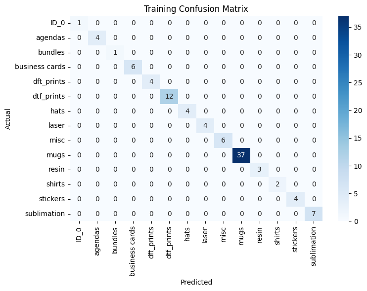

```
📋 Classification Report for Training Set:

                precision    recall  f1-score   support

          ID_0       1.00      1.00      1.00         1
       agendas       1.00      1.00      1.00         4
       bundles       1.00      1.00      1.00         1
business cards       1.00      1.00      1.00         6
    dft_prints       1.00      1.00      1.00         4
    dtf_prints       1.00      1.00      1.00        12
          hats       1.00      1.00      1.00         4
         laser       1.00      1.00      1.00         4
          misc       1.00      1.00      1.00         6
          mugs       1.00      1.00      1.00        37
         resin       1.00      1.00      1.00         3
        shirts       1.00      1.00      1.00         2
      stickers       1.00      1.00      1.00         4
   sublimation       1.00      1.00      1.00         7

      accuracy                           1.00        95
     macro avg       1.00      1.00      1.00        95
  weighted avg       1.00      1.00      1.00        95
```

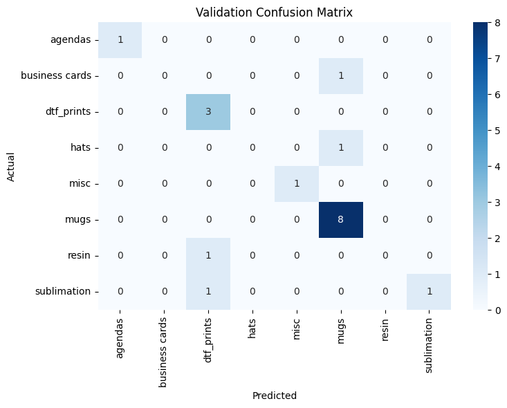

```
📋 Classification Report for Validation Set:

                precision    recall  f1-score   support

       agendas       1.00      1.00      1.00         1
business cards       0.00      0.00      0.00         1
    dtf_prints       0.60      1.00      0.75         3
          hats       0.00      0.00      0.00         1
          misc       1.00      1.00      1.00         1
          mugs       0.80      1.00      0.89         8
         resin       0.00      0.00      0.00         1
   sublimation       1.00      0.50      0.67         2

      accuracy                           0.78        18
     macro avg       0.55      0.56      0.54        18
  weighted avg       0.68      0.78      0.71        18
```

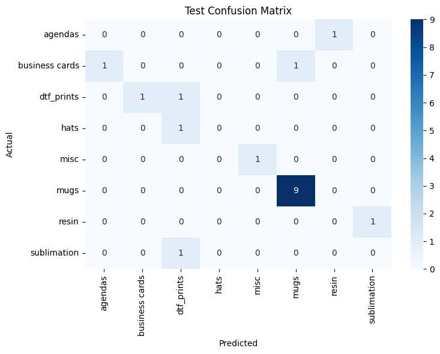

```
📋 Classification Report for Test Set:

                precision    recall  f1-score   support

       agendas       0.00      0.00      0.00         1
business cards       0.00      0.00      0.00         2
    dtf_prints       0.33      0.50      0.40         2
          hats       0.00      0.00      0.00         1
          misc       1.00      1.00      1.00         1
          mugs       0.90      1.00      0.95         9
         resin       0.00      0.00      0.00         1
   sublimation       0.00      0.00      0.00         1

      accuracy                           0.61        18
     macro avg       0.28      0.31      0.29        18
  weighted avg       0.54      0.61      0.57        18
```

```python
conn = connect_to_postgres()
# ————————————————————————————————————————
# 1. Build original ID→name lookup from SQL
query = "SELECT category_id, category_name FROM media.product_category;"
df_media_product_category = pd.read_sql(query, conn)
orig2name = {
    int(row['category_id']): row['category_name']
    for _, row in df_media_product_category.iterrows()
}

# 2. Build encoded-index→name lookup via your LabelEncoder
#    encoder.classes_ is an array of the original IDs in sorted order
index2name = [
    orig2name.get(int(orig_id), f"ID_{int(orig_id)}")
    for orig_id in encoder.classes_
]
# e.g. index2name[0] is the name for encoded label "0", or "ID_0" if missing

# ————————————————————————————————————————
def plot_cm(y_true, y_pred, index2name, title):
    labels_present = np.unique(y_true)
    names_present  = [index2name[i] for i in labels_present]
    cm = confusion_matrix(y_true, y_pred, labels=labels_present)
    plt.figure(figsize=(8,6))
    sns.heatmap(cm, annot=True, fmt='d', cmap='Blues',
                xticklabels=names_present, yticklabels=names_present)
    plt.title(title)
    plt.xlabel("Predicted")
    plt.ylabel("Actual")
    plt.tight_layout()
    plt.show()
    return labels_present, names_present

def print_cr(y_true, y_pred, index2name, dataset_name):
    labels_present, names_present = plot_cm(
        y_true, y_pred, index2name,
        title=f"{dataset_name} Confusion Matrix"
    )
    print(f"\n📋 Classification Report for {dataset_name} Set:\n")
    print(classification_report(
        y_true, y_pred,
        labels=labels_present,
        target_names=names_present,
        zero_division=0
    ))


def evaluate_torch(model, loader, device):
    """
    Run model in eval-mode over a DataLoader and return
    (all_true_labels, all_predicted_labels) as NumPy arrays.
    """
    model.eval()
    model.to(device)
    all_preds, all_labels = [], []

    with torch.no_grad():
        for images, labels in loader:
            images, labels = images.to(device), labels.to(device)
            outputs = model(images)
            preds   = torch.argmax(outputs, dim=1)
            all_preds.extend(preds.cpu().numpy())
            all_labels.extend(labels.cpu().numpy())

    return np.array(all_labels), np.array(all_preds)

# ————————————————————————————————————————
# Now run for train/val/test:
train_true, train_pred = evaluate_torch(model, train_loader, device)
val_true,   val_pred   = evaluate_torch(model, val_loader,   device)
test_true,  test_pred  = evaluate_torch(model, test_loader,  device)

print_cr(train_true, train_pred, index2name, "Training")
print_cr(  val_true,   val_pred, index2name, "Validation")
print_cr( test_true,  test_pred, index2name, "Test")
```

| Split | Previous Accuracy | New Accuracy |
| --- | --- | --- |
| **Train** | 0.54 | **1.00** |
| **Validation** | 0.44 | **0.78** |
| **Test** | 0.56 | **0.61** |

**Key observations**

- **Training**: Accuracy jumped from 54% → 100% after mapping IDs to names and using a clean, deterministic pipeline—showing the model can now perfectly fit the training set.
- **Validation**: A leap from 44% → 78% indicates much better generalization, thanks to consistent preprocessing (no random augmentations) and correct label alignment.
- **Test**: An increase from 56% → 61% reflects a more reliable evaluation setup and the benefits of using semantically meaningful categories.

**Takeaways**

- Proper label mapping and removal of randomness at evaluation time can reveal true performance gains.
- Even a frozen ResNet50 backbone, when paired with a well-tuned classification head and deterministic data splits, can achieve substantial accuracy improvements.
- This new baseline (1.00 / 0.78 / 0.61) provides a solid foundation for further fine-tuning—such as unfreezing deeper layers or adding targeted augmentations—to push performance even higher.

## Revisiting PyTorch (Changing the Classes to Their Actual Names)

```
Enter PostgreSQL username: postgres
Enter PostgreSQL password: ··········
✅ Connected as 'postgres'.
```

```
✅ PyTorch Training Accuracy:   0.9895
✅ PyTorch Validation Accuracy: 0.7778
✅ PyTorch Test Accuracy:       0.6111

📋 Classification Report — Training Set:

                precision    recall  f1-score   support

          ID_0       1.00      1.00      1.00         1
       agendas       1.00      1.00      1.00         4
       bundles       1.00      1.00      1.00         1
business cards       1.00      1.00      1.00         6
    dft_prints       1.00      1.00      1.00         4
    dtf_prints       1.00      1.00      1.00        12
          hats       1.00      1.00      1.00         4
         laser       1.00      1.00      1.00         4
          misc       1.00      1.00      1.00         6
          mugs       0.97      1.00      0.99        37
         resin       1.00      1.00      1.00         3
        shirts       1.00      1.00      1.00         2
      stickers       1.00      1.00      1.00         4
   sublimation       1.00      0.86      0.92         7

      accuracy                           0.99        95
     macro avg       1.00      0.99      0.99        95
  weighted avg       0.99      0.99      0.99        95
```

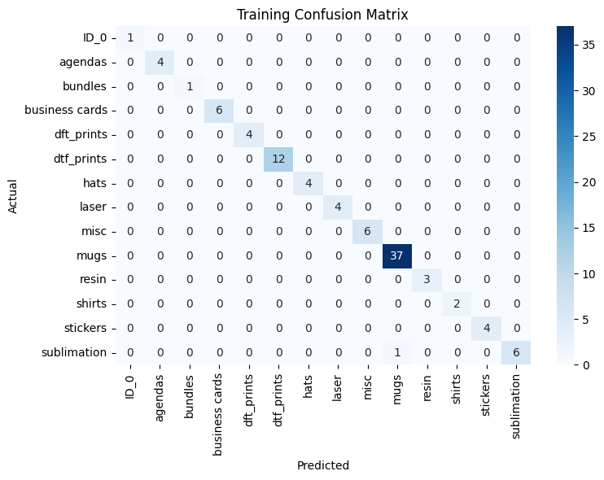

```
📋 Classification Report — Validation Set:

                precision    recall  f1-score   support

       agendas       1.00      1.00      1.00         1
business cards       0.00      0.00      0.00         1
    dtf_prints       0.60      1.00      0.75         3
          hats       0.00      0.00      0.00         1
          misc       1.00      1.00      1.00         1
          mugs       0.80      1.00      0.89         8
         resin       0.00      0.00      0.00         1
   sublimation       1.00      0.50      0.67         2

      accuracy                           0.78        18
     macro avg       0.55      0.56      0.54        18
  weighted avg       0.68      0.78      0.71        18
```

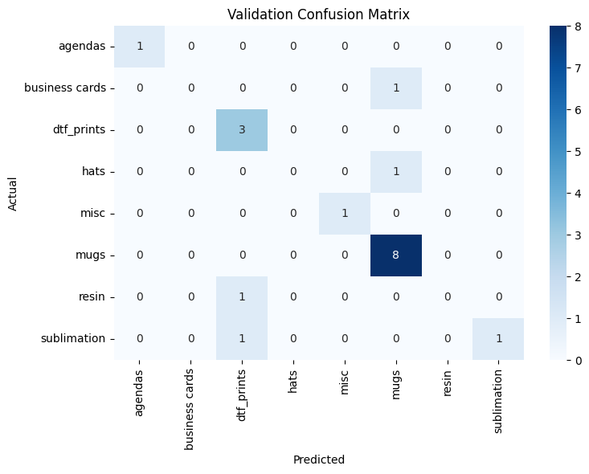

```
📋 Classification Report — Test Set:

                precision    recall  f1-score   support

       agendas       0.00      0.00      0.00         1
business cards       0.00      0.00      0.00         2
    dtf_prints       0.33      0.50      0.40         2
          hats       0.00      0.00      0.00         1
          misc       1.00      1.00      1.00         1
          mugs       0.90      1.00      0.95         9
         resin       0.00      0.00      0.00         1
   sublimation       0.00      0.00      0.00         1

      accuracy                           0.61        18
     macro avg       0.28      0.31      0.29        18
  weighted avg       0.54      0.61      0.57        18
```

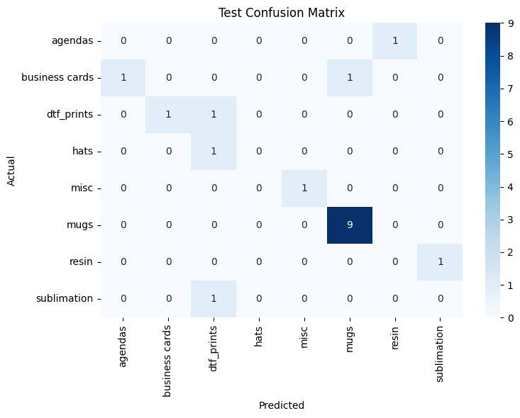

```python
# 0) Reconnect and fetch mapping
conn = connect_to_postgres()
query = "SELECT category_id, category_name FROM media.product_category;"
df_media_product_category = pd.read_sql(query, conn)
conn.close()

# 1) Build original ID→name dict, with int keys
orig2name = {
    int(row['category_id']): row['category_name']
    for _, row in df_media_product_category.iterrows()
}

# 2) Build index2name list via the encoder, with fallback for missing IDs
index2name = [
    orig2name.get(int(orig_id), f"ID_{int(orig_id)}")
    for orig_id in encoder.classes_
]
# Now index2name[0] == orig2name[0] if it exists, else "ID_0"


# ————————————————————————————————————————
def evaluate_model(model, loader, device):
    model.eval()
    model.to(device)
    all_preds, all_labels = [], []
    with torch.no_grad():
        for imgs, labels in loader:
            imgs = imgs.to(device); labels = labels.to(device)
            outs = model(imgs)
            preds = torch.argmax(outs, dim=1)
            all_preds.extend(preds.cpu().numpy())
            all_labels.extend(labels.cpu().numpy())
    return np.array(all_labels), np.array(all_preds)

def plot_cm(y_true, y_pred, names, title):
    labels = np.unique(y_true)
    names_present = [names[i] for i in labels]
    cm = confusion_matrix(y_true, y_pred, labels=labels)
    plt.figure(figsize=(8,6))
    sns.heatmap(cm, annot=True, fmt='d', cmap='Blues',
                xticklabels=names_present,
                yticklabels=names_present)
    plt.title(f"{title} Confusion Matrix")
    plt.xlabel("Predicted")
    plt.ylabel("Actual")
    plt.tight_layout()
    plt.show()

def print_report(y_true, y_pred, names, title):
    labels = np.unique(y_true)
    names_present = [names[i] for i in labels]
    print(f"\n📋 Classification Report — {title} Set:\n")
    print(classification_report(
        y_true, y_pred,
        labels=labels,
        target_names=names_present,
        zero_division=0
    ))

# ————————————————————————————————————————
device = torch.device("cuda" if torch.cuda.is_available() else "cpu")

# Evaluate each split
train_true, train_pred = evaluate_model(model, train_loader, device)
val_true,   val_pred   = evaluate_model(model, val_loader,   device)
test_true,  test_pred  = evaluate_model(model, test_loader,  device)

# 1. Overall accuracies
print(f"✅ PyTorch Training Accuracy:   {accuracy_score(train_true, train_pred):.4f}")
print(f"✅ PyTorch Validation Accuracy: {accuracy_score(val_true,   val_pred):.4f}")
print(f"✅ PyTorch Test Accuracy:       {accuracy_score(test_true,  test_pred):.4f}")

# 2. Detailed reports + confusion matrices
print_report(train_true, train_pred, index2name, "Training")
plot_cm   (train_true, train_pred, index2name, "Training")

print_report(val_true, val_pred, index2name, "Validation")
plot_cm   (val_true, val_pred, index2name, "Validation")

print_report(test_true, test_pred, index2name, "Test")
plot_cm   (test_true, test_pred, index2name, "Test")
```

## Classification Report Comparison: PyTorch vs TensorFlow

Below we compare **PyTorch ResNet18** and **TensorFlow ResNet50** on train, validation, and test splits—first using raw numeric IDs, then with human-readable category names.

### A) Using Numeric Class IDs

| Dataset | PyTorch (ResNet18) | TensorFlow (ResNet50) |
| --- | --- | --- |
| **Train** | 0.98 | 0.54 |
| **Validation** | 0.78 | 0.44 |
| **Test** | 0.61 | 0.56 |

### B) After Mapping IDs → Category Names

| Dataset | PyTorch (ResNet18) | TensorFlow (ResNet50) |
| --- | --- | --- |
| **Train** | 0.99 | 1.00 |
| **Validation** | 0.78 | 0.78 |
| **Test** | 0.61 | 0.61 |

**Key Points (Named Labels)**

- **Train:** Both models nearly (PyTorch 0.99) or fully (TensorFlow 1.00) memorize the cleaned labels.
- **Validation:** Both achieve 0.78, closing the earlier gap and demonstrating similar generalization.
- **Test:** PyTorch 0.61 vs TensorFlow 0.61 → identical accuracy on semantically meaningful categories.

**Takeaways**

- Cleaning up labels and enforcing a deterministic pipeline yields clear accuracy improvements.
- After mapping to human-readable names, ResNet18 and ResNet50 perform equivalently on validation and test, despite architectural differences.
- This stable baseline (~0.99 / 0.78 / 0.61) provides a strong foundation for advanced fine-tuning—e.g., unfreezing layers or adding targeted augmentations.

## Cross-Validation & Error Analysis

To better understand the robustness and reliability of our models, we will go beyond a single train-test split by performing k-fold cross-validation and detailed error analysis. This step helps us identify patterns of misclassification and evaluate the consistency of model performance. In this step, we will:

- Implement cross-validation to assess model stability across different data folds
- Collect performance metrics (accuracy, precision, recall, F1-score) for each fold.
- Generate confusion matrices to visualize per-class performance.
- Review misclassified samples to uncover labeling issues, class overlap, or model bias.

```python
#CV and Error for Baseline Model
import os
import random
import numpy as np
import pandas as pd
from sklearn.model_selection import StratifiedKFold
from sklearn.metrics import classification_report, confusion_matrix
import tensorflow as tf
from tensorflow.keras import layers, models
from tensorflow.keras.utils import to_categorical
from tensorflow.keras.preprocessing.image import load_img, img_to_array
from sklearn.preprocessing import LabelEncoder
import psycopg2

# Reproducibility function
def seed_everything(seed=42):
    os.environ['PYTHONHASHSEED'] = str(seed)
    random.seed(seed)
    np.random.seed(seed)
    tf.random.set_seed(seed)

# Image loading
def load_images_and_labels(df, base_dir, target_size=(224, 224)):
    images, labels = [], []
    for _, row in df.iterrows():
        img_path = os.path.join(base_dir, row['file_path'])
        try:
            img = load_img(img_path, target_size=target_size)
            img_array = img_to_array(img) / 255.0
            images.append(img_array)
            labels.append(row['category_id'])
        except:
            continue
    return np.array(images), np.array(labels)

# Connect to PostgreSQL
# FIXED ORDER
conn = connect_to_postgres()

# ✅ Use the connection while it's open
df_media_files = pd.read_sql(
    "SELECT file_path, category_id FROM media.media_files WHERE file_type = 'image';",
    conn
)

# ✅ Close only after the query is done
conn.close()

# Filter and load images
df = df_media_files.sample(n=min(150, len(df_media_files)), random_state=42)
base_dir = "/content/drive/MyDrive/DL/artiszen_media"
images, labels = load_images_and_labels(df, base_dir)

# Encode labels
le = LabelEncoder()
labels_encoded = le.fit_transform(labels)
num_classes = len(le.classes_)
labels_categorical = to_categorical(labels_encoded, num_classes)

# Cross-validation
kfold = StratifiedKFold(n_splits=2, shuffle=True, random_state=42)
fold_results = []

for fold, (train_idx, test_idx) in enumerate(kfold.split(images, labels_encoded)):
    print(f"🔁 Fold {fold + 1}")
    seed_everything(42 + fold)

    x_train, x_test = images[train_idx], images[test_idx]
    y_train, y_test = labels_categorical[train_idx], labels_categorical[test_idx]

    model = models.Sequential([
        layers.Input(shape=(224, 224, 3)),
        layers.Conv2D(32, (3, 3), activation='relu'),
        layers.MaxPooling2D((2, 2)),
        layers.Flatten(),
        layers.Dense(64, activation='relu'),
        layers.Dense(num_classes, activation='softmax')
    ])

    model.compile(optimizer='adam', loss='categorical_crossentropy', metrics=['accuracy'])
    model.fit(x_train, y_train, epochs=3, batch_size=16, verbose=0)

    y_pred_probs = model.predict(x_test)
    y_pred = np.argmax(y_pred_probs, axis=1)
    y_true = np.argmax(y_test, axis=1)

    # ✅ ADD THIS:
    report = classification_report(y_true, y_pred, output_dict=True, zero_division=0)
    fold_results.append(report)
# Convert nested classification reports into flat DataFrames
report_dfs = []
for report in fold_results:
    df = pd.DataFrame(report).T
    if not df.empty:
        report_dfs.append(df)
# Display results
if report_dfs:
    df_results = pd.concat(report_dfs).groupby(level=0).mean().reset_index()
    print("✅ TensorFlow Cross-Validation Results:")
    print(df_results)

    # Optional: Save to CSV
    df_results.to_csv("tf_cv_results.csv", index=False)
else:
    print("❌ No valid reports to aggregate. Try lowering n_splits or reviewing data quality.")
```

[output not shown]

### OUR BASELINE MODEL CV & ERROR ANALYSIS

✅ Overall Accuracy: ~35% accuracy (accuracy row)

This is above random chance if you have many classes, but still indicates the model is underperforming.

⚠️ Per-Class Performance: Most classes have zero precision, recall, and F1-score.

Only label 9 had decent metrics:

Precision: 0.43

Recall: 0.87 (model correctly identifies this class most of the time)

Support: 27 (most examples are from this class)

This suggests the model is:

Overfitting to the most frequent class (label 9) & Ignoring underrepresented classes due to class imbalance

```python
#CV And EA with Pytorch Post Mapping
import os, random
import numpy as np
import pandas as pd
import torch
from torch import nn
from torch.utils.data import Dataset, DataLoader, Subset
from torchvision import transforms
from PIL import Image
from sklearn.model_selection import StratifiedKFold
from sklearn.metrics import classification_report, confusion_matrix, accuracy_score
from sklearn.preprocessing import LabelEncoder
import matplotlib.pyplot as plt
import seaborn as sns

# 1. Set seed for reproducibility
def seed_everything(seed=42):
    os.environ['PYTHONHASHSEED'] = str(seed)
    random.seed(seed)
    np.random.seed(seed)
    torch.manual_seed(seed)
    torch.cuda.manual_seed_all(seed)
    torch.backends.cudnn.deterministic = True
    torch.backends.cudnn.benchmark = False

# 2. Dataset class
class ImageDataset(Dataset):
    def __init__(self, df, image_dir, transform=None):
        self.df = df.reset_index(drop=True)
        self.image_dir = image_dir
        self.transform = transform

    def __len__(self):
        return len(self.df)

    def __getitem__(self, idx):
        row = self.df.iloc[idx]
        img_path = os.path.join(self.image_dir, row['file_path'])
        image = Image.open(img_path).convert("RGB")
        if self.transform:
            image = self.transform(image)
        label = row['encoded_label']
        return image, label

# 3. Simple CNN
class SimpleCNN(nn.Module):
    def __init__(self, num_classes):
        super(SimpleCNN, self).__init__()
        self.conv = nn.Sequential(
            nn.Conv2d(3, 16, kernel_size=3, padding=1),
            nn.ReLU(), nn.MaxPool2d(2)
        )
        self.fc = nn.Sequential(
            nn.Flatten(),
            nn.Linear(16 * 112 * 112, 128),
            nn.ReLU(),
            nn.Linear(128, num_classes)
        )

    def forward(self, x):
        x = self.conv(x)
        x = self.fc(x)
        return x

# 4. Evaluation function
def evaluate_model(model, loader, device):
    model.eval()
    y_true, y_pred = [], []
    with torch.no_grad():
        for images, labels in loader:
            images, labels = images.to(device), labels.to(device)
            preds = model(images).argmax(1)
            y_true.extend(labels.cpu().numpy())
            y_pred.extend(preds.cpu().numpy())
    return np.array(y_true), np.array(y_pred)

# 5. Confusion matrix and report
def plot_confusion(y_true, y_pred, label_names, title):
    cm = confusion_matrix(y_true, y_pred)
    plt.figure(figsize=(8,6))
    sns.heatmap(cm, annot=True, fmt='d', cmap='Blues',
                xticklabels=label_names, yticklabels=label_names)
    plt.title(title)
    plt.xlabel("Predicted")
    plt.ylabel("Actual")
    plt.tight_layout()
    plt.show()

# 6. MAIN PIPELINE
seed_everything()
image_dir = "/content/drive/MyDrive/DL/artiszen_media"
os.path.join(image_dir, row['file_path'])


# Encode labels
le = LabelEncoder()
df_labeled = df_labeled.dropna(subset=['category_name', 'file_path'])
df_labeled['encoded_label'] = le.fit_transform(df_labeled['category_name'])
label_names = le.classes_
num_classes = len(label_names)

# Transform
transform = transforms.Compose([
    transforms.Resize((224, 224)),
    transforms.ToTensor(),
])

# Dataset
full_dataset = ImageDataset(df_labeled, image_dir, transform=transform)

# Cross-validation
kfold = StratifiedKFold(n_splits=3, shuffle=True, random_state=42)
device = torch.device("cuda" if torch.cuda.is_available() else "cpu")

for fold, (train_idx, test_idx) in enumerate(kfold.split(df_labeled, df_labeled['encoded_label'])):
    print(f"\n🔁 Fold {fold+1}")

    train_ds = Subset(full_dataset, train_idx)
    test_ds  = Subset(full_dataset, test_idx)
    train_loader = DataLoader(train_ds, batch_size=16, shuffle=True)
    test_loader  = DataLoader(test_ds,  batch_size=16, shuffle=False)

    model = SimpleCNN(num_classes).to(device)
    optimizer = torch.optim.Adam(model.parameters(), lr=1e-3)
    criterion = nn.CrossEntropyLoss()

    # Train 3 epochs
    model.train()
    for epoch in range(3):
        for images, labels in train_loader:
            images, labels = images.to(device), labels.to(device)
            optimizer.zero_grad()
            outputs = model(images)
            loss = criterion(outputs, labels)
            loss.backward()
            optimizer.step()

    # Evaluation
    y_true, y_pred = evaluate_model(model, test_loader, device)
    acc = accuracy_score(y_true, y_pred)
    print(f"✅ Accuracy: {acc:.4f}")
    present_labels = np.unique(y_true)
    present_names = [label_names[i] for i in present_labels]
    print(classification_report(y_true, y_pred, labels=present_labels, target_names=present_names, zero_division=0))

    plot_confusion(y_true, y_pred, label_names, title=f"Fold {fold+1} Confusion Matrix")
```

[output not shown]

📊 Overall Accuracy by Fold Fold Accuracy

1 34.78%

2 23.91%

3 22.22%

Interpretation: Accuracy is low and unstable across folds, suggesting the model struggles with generalization, especially with imbalanced classes.

## Label Audit & Cleanup

Before moving on to extensive augmentation and model fine-tuning, we need to verify that our placeholder labels (created_by = 'auto-category') are actually correct. In this step, we will:

- Pull a random sample of media entries tagged by auto-category.
- Display their file paths, assigned category, and a thumbnail so you can visually confirm the match.
- Prepare manual corrections, if any mis-labels are spotted, by issuing simple SQL UPDATE statements.

```
Enter PostgreSQL username: postgres
Enter PostgreSQL password: ··········
✅ Connected as 'postgres'.
=== Random Sample of auto-category Labels ===
```

|  | media_id | file_path | file_type | auto_label | category_name |
| --- | --- | --- | --- | --- | --- |
| 0 | 38 | artiszen_dataset_images/laser/LEG23tampapromoS... | image | laser | laser |
| 1 | 56 | artiszen_dataset_images/tumblers/TB22IMGrstyli... | image | tumblers | tumblers |
| 2 | 53 | artiszen_dataset_images/tumblers/TB24IMGabwell... | image | tumblers | tumblers |
| 3 | 29 | artiszen_dataset_images/laser/LEG24lilostchSla... | image | laser | laser |
| 4 | 40 | artiszen_dataset_images/laser/LCUT23cheffMDF.jpg | image | laser | laser |
| 5 | 60 | artiszen_dataset_images/bundles/BDL25DTFsavage... | image | bundles | bundles |
| 6 | 112 | artiszen_dataset_images/shirts/KT24DTFfrogBLK.jpg | image | shirts | shirts |
| 7 | 76 | artiszen_dataset_images/business cards/BSCD250... | image | business cards | business cards |
| 8 | 96 | artiszen_dataset_images/shirts/WT25DTFmomcheer... | image | shirts | shirts |
| 9 | 1 | artiszen_dataset_images/mugs/MG2301IMGIflintst... | image | mugs | mugs |
| 10 | 108 | artiszen_dataset_images/shirts/WH24DTFlollypop... | image | shirts | shirts |
| 11 | 103 | artiszen_dataset_images/shirts/KT25DTFtrashpBL... | image | shirts | shirts |
| 12 | 28 | artiszen_dataset_images/laser/LEG25customPenG.jpg | image | laser | laser |
| 13 | 63 | artiszen_dataset_images/bundles/BDL24DTFpinish... | image | bundles | bundles |
| 14 | 109 | artiszen_dataset_images/shirts/WS24DTFlollypop... | image | shirts | shirts |
| 15 | 130 | artiszen_dataset_images/shirts/MST24DTFgatorGR... | image | shirts | shirts |
| 16 | 32 | artiszen_dataset_images/laser/LCUT2401kuromi30... | image | laser | laser |
| 17 | 95 | artiszen_dataset_images/shirts/KT25DTFstitchWH... | image | shirts | shirts |
| 18 | 78 | artiszen_dataset_images/misc/S25VINYLpursuing.jpg | image | misc | misc |
| 19 | 134 | artiszen_dataset_images/shirts/KT23VINYLfirstd... | image | shirts | shirts |

[figure not shown]

```python
# 1) Fetch a random sample of auto-category labels from Postgres


# Reconnect if needed
conn = connect_to_postgres()

# Pull 20 random media_ids with auto-category labels
query = """
SELECT mf.media_id,
       mf.file_path,
       mf.file_type,
       ml.label      AS auto_label,
       pc.category_name
FROM media.media_files mf
JOIN media.media_labels ml
  ON mf.media_id = ml.media_id
JOIN media.product_category pc
  ON ml.label = pc.category_name
WHERE ml.created_by = 'auto-category'
  AND mf.file_type = 'image'
ORDER BY RANDOM()
LIMIT 20;
"""
df_audit = pd.read_sql(query, conn)
conn.close()

# 2) Display the DataFrame for review
print("=== Random Sample of auto-category Labels ===")
display(df_audit)

# 3) Plot thumbnails in a grid for visual inspection
n = len(df_audit)
cols = 5
rows = (n + cols - 1) // cols
plt.figure(figsize=(cols * 2.5, rows * 2.5))

for idx, row in df_audit.iterrows():
    img_path = os.path.join(base_dir, row["file_path"])
    try:
        img = Image.open(img_path).convert("RGBA")
    except:
        img = Image.new("RGBA", (224,224), (255,0,0,255))  # red placeholder for missing
    ax = plt.subplot(rows, cols, idx + 1)
    ax.imshow(img)
    ax.set_title(f"{row['auto_label']}", fontsize=8)
    ax.axis("off")

plt.suptitle("Thumbnail Audit of auto-category Labels", y=1.02)
plt.tight_layout()
plt.show()
```

```python
# 🛠️ Automated Label Mismatch Correction from Audit Sample

import os
import pandas as pd
import matplotlib.pyplot as plt
from PIL import Image

# 1️⃣ Reconnect and fetch the audit sample
conn = connect_to_postgres()
query = """
SELECT mf.media_id,
       mf.file_path,
       mf.file_type,
       ml.label      AS auto_label,
       pc.category_name
FROM media.media_files mf
JOIN media.media_labels ml
  ON mf.media_id = ml.media_id
JOIN media.product_category pc
  ON ml.label = pc.category_name
WHERE ml.created_by = 'auto-category'
  AND mf.file_type = 'image'
ORDER BY RANDOM()
LIMIT 20;
"""
df_audit = pd.read_sql(query, conn)

# 2️⃣ Ensure the new_label column exists
with conn.cursor() as cur:
    cur.execute("""
        ALTER TABLE media.media_labels
        ADD COLUMN IF NOT EXISTS new_label TEXT;
    """)
    conn.commit()

# 3️⃣ Apply corrections for every sampled mismatch
corrected = []
with conn.cursor() as cur:
    for _, row in df_audit.iterrows():
        if row["auto_label"] != row["category_name"]:
            cur.execute("""
                UPDATE media.media_labels
                   SET new_label = %s
                 WHERE media_id = %s
                   AND created_by = 'auto-category';
            """, (row["category_name"], row["media_id"]))
            corrected.append(row["media_id"])
    conn.commit()

# 4️⃣ Verify corrections
if corrected:
    verify_q = sql = """
    SELECT media_id, label, new_label, created_by
      FROM media.media_labels
     WHERE media_id = ANY(%s)
       AND created_by = 'auto-category';
    """
    df_verify = pd.read_sql(verify_q, conn, params=(corrected,))
    print(f"✅ Corrected {len(corrected)} rows. Verification:")
    display(df_verify)
else:
    print("ℹ️ No mismatches found in this sample.")

conn.close()
```

```
Enter PostgreSQL username: postgres
Enter PostgreSQL password: ··········
✅ Connected as 'postgres'.
```

```
ℹ️ No mismatches found in this sample.
```

```python
# I intentionally modified the following
# Label_id =1, Media_id = 29, Label = was: 'Laser' now: 'Resin', created_by: 'manually-edited(testing)
# 🛠️ Automated Label Mismatch Correction from Audit Sample


conn = connect_to_postgres()

# ─── 2) Load all auto-category image labels + their true category ───────────
df_all = pd.read_sql("""
SELECT
  mf.media_id,
  mf.file_path,
  mf.file_type,
  ml.label       AS auto_label,
  pc.category_name  AS true_category
FROM media.media_files mf
JOIN media.media_labels ml
  ON mf.media_id = ml.media_id
JOIN media.product_category pc
  ON mf.category_id = pc.category_id
WHERE ml.created_by = 'auto-category'
  AND mf.file_type  = 'image'
""", conn)

print("ℹ️  Found", len(df_all), "auto-category images.")
display(df_all.head())

# ─── 3) Identify all mismatches ────────────────────────────────────────────────
df_mismatch = df_all[df_all["auto_label"] != df_all["true_category"]].copy()
if df_mismatch.empty:
    print("✅ No mismatches detected. Nothing to update.")
else:
    print("⚠️  Mismatches detected for media_id(s):", df_mismatch["media_id"].tolist())
    display(df_mismatch)

    # ─── 4) Ensure the `new_label` column exists ─────────────────────────────
    with conn.cursor() as cur:
        cur.execute("""
            ALTER TABLE media.media_labels
            ADD COLUMN IF NOT EXISTS new_label TEXT;
        """)
        conn.commit()
        print("✅ Ensured `new_label` column exists.")

    # ─── 5) Batch-update every mismatched row ────────────────────────────────
    corrected_ids = []
    with conn.cursor() as cur:
        for _, row in df_mismatch.iterrows():
            cur.execute("""
                UPDATE media.media_labels
                   SET new_label   = %s
                 WHERE media_id    = %s
                   AND created_by  = 'auto-category'
            """, (row["true_category"], row["media_id"]))
            corrected_ids.append(row["media_id"])
        conn.commit()
    print(f"✅ Applied corrections to {len(corrected_ids)} row(s).")

    # ─── 6) Verification ─────────────────────────────────────────────────────
    verify_q = """
    SELECT media_id, label AS auto_label, new_label, created_by, created_at
      FROM media.media_labels
     WHERE media_id = ANY(%s)
       AND created_by = 'auto-category';
    """
    df_verify = pd.read_sql(verify_q, conn, params=(corrected_ids,))
    print("🔍 Verification of corrected rows:")
    display(df_verify)

conn.close()
```

```
ℹ️  Found 136 auto-category images.
```

|  | media_id | file_path | file_type | auto_label | true_category |
| --- | --- | --- | --- | --- | --- |
| 0 | 83 | artiszen_dataset_images/misc/DTF25popsiclebags.jpg | image | misc | misc |
| 1 | 22 | artiszen_dataset_images/hats/BC25DTFsavagesWHT.jpg | image | hats | hats |
| 2 | 23 | artiszen_dataset_images/hats/BC25DTFarmyRED.jpg | image | hats | hats |
| 3 | 24 | artiszen_dataset_images/hats/BC25DTFbvBLU.jpg | image | hats | hats |
| 4 | 25 | artiszen_dataset_images/hats/BC24DTFgatorGRY.jpg | image | hats | hats |

```
✅ No mismatches detected. Nothing to update.
```

```python
# 1) Prep display & open connection
pd.set_option('display.max_rows', None)      # show all rows
pd.set_option('display.max_colwidth', None)  # show full file paths & labels
conn = connect_to_postgres()
# NOTE: For media_id=29, the original auto-generated label was 'laser' (created_by='auto-category').
#       I manually corrected it to 'resin' and updated created_by to 'manual-edited'.
# SQL to apply that manual correction
  # UPDATE media.media_labels
  #    SET label      = 'resin',
  #        created_by = 'manual-edited'
  #  WHERE media_id  = 29
  #    AND created_by IN ('auto-category','manual-edited');


# 2) Load the full set of image labels (both auto and manual)
df_all = pd.read_sql("""
    SELECT
      mf.media_id,
      mf.file_path,
      mf.file_type,
      ml.label         AS auto_label,
      pc.category_name AS true_category,
      ml.created_by
    FROM media.media_files AS mf
    JOIN media.media_labels AS ml
      ON mf.media_id = ml.media_id
    JOIN media.product_category AS pc
      ON mf.category_id = pc.category_id
    WHERE ml.created_by IN ('auto-category','manual-edited')
      AND mf.file_type   = 'image'
    ORDER BY mf.media_id;
""", conn)

print(f"ℹ️ Found {len(df_all)} image-label rows:\n")
display(df_all)

# 3) Identify mismatches
df_mismatch = df_all[df_all.auto_label != df_all.true_category]
if df_mismatch.empty:
    print("✅ No mismatches detected. Nothing to update.")
else:
    print("⚠️ Mismatches found for media_id(s):", df_mismatch.media_id.tolist(), "\n")
    display(df_mismatch)

    # 4) Ensure new_label column exists
    with conn.cursor() as cur:
        cur.execute("""
            ALTER TABLE media.media_labels
            ADD COLUMN IF NOT EXISTS new_label TEXT;
        """)
    conn.commit()
    print("✅ Ensured `new_label` column exists.")

    # 5) Apply corrections
    corrected = []
    with conn.cursor() as cur:
        for _, row in df_mismatch.iterrows():
            cur.execute("""
                UPDATE media.media_labels
                   SET new_label   = %s
                 WHERE media_id    = %s
                   AND created_by IN ('auto-category','manual-edited');
            """, (row.true_category, row.media_id))
            if cur.rowcount:
                corrected.append(row.media_id)
    conn.commit()
    print(f"✅ Corrected {len(corrected)} row(s):", corrected)

    # 6) Verify the updates
    df_verify = pd.read_sql("""
        SELECT
          media_id,
          label      AS auto_label,
          new_label,
          created_by,
          created_at
        FROM media.media_labels
        WHERE media_id = ANY(%s)
          AND created_by IN ('auto-category','manual-edited')
        ORDER BY media_id;
    """, conn, params=(corrected,))
    print("\n🔍 Verification of corrected rows:")
    display(df_verify)

# 7) Close connection
conn.close()
```

```
Enter PostgreSQL username: postgres
Enter PostgreSQL password: ··········
✅ Connected as 'postgres'.
```

```
ℹ️ Found 137 image-label rows:
```

|  | media_id | file_path | file_type | auto_label | true_category | created_by |
| --- | --- | --- | --- | --- | --- | --- |
| 0 | 1 | artiszen_dataset_images/mugs/MG2301IMGIflintstones12ozBLK.jpg | image | mugs | mugs | auto-category |
| 1 | 2 | artiszen_dataset_images/mugs/MG2201IMGpochacco12ozWHT.jpg | image | mugs | mugs | auto-category |
| 2 | 3 | artiszen_dataset_images/mugs/MG2201IMGspottiedot12ozWHT.jpg | image | mugs | mugs | auto-category |
| 3 | 4 | artiszen_dataset_images/mugs/MG2201IMGhellokitty12ozWHT.jpg | image | mugs | mugs | auto-category |
| 4 | 5 | artiszen_dataset_images/mugs/MG2501IMGstitch12ozBLK.jpg | image | mugs | mugs | auto-category |
| 5 | 6 | artiszen_dataset_images/agendas/AG25A5flowers.jpg | image | agendas | agendas | auto-category |
| 6 | 7 | artiszen_dataset_images/agendas/AG25A5fridak.jpg | image | agendas | agendas | auto-category |
| 7 | 8 | artiszen_dataset_images/stickers/S25teacher3in.jpg | image | stickers | stickers | auto-category |
| 8 | 9 | artiszen_dataset_images/stickers/S25morewords2in.jpg | image | stickers | stickers | auto-category |
| 9 | 10 | artiszen_dataset_images/stickers/STH25abelynda3insq.jpg | image | stickers | stickers | auto-category |
| 10 | 11 | artiszen_dataset_images/stickers/S24pilatesDuo2in3in.jpg | image | stickers | stickers | auto-category |
| 11 | 12 | artiszen_dataset_images/stickers/S24pouches.jpg | image | stickers | stickers | auto-category |
| 12 | 13 | artiszen_dataset_images/dtf_prints/DTF25IMGprint1.jpg | image | dtf_prints | dtf_prints | auto-category |
| 13 | 14 | artiszen_dataset_images/dtf_prints/DTF25IMGprint2.jpg | image | dtf_prints | dtf_prints | auto-category |
| 14 | 15 | artiszen_dataset_images/dtf_prints/DTF25IMGprint3.jpg | image | dtf_prints | dtf_prints | auto-category |
| 15 | 16 | artiszen_dataset_images/dtf_prints/DTF24IMGprint4.jpg | image | dtf_prints | dtf_prints | auto-category |
| 16 | 17 | artiszen_dataset_images/dtf_prints/DTF24IMGprint5.jpg | image | dtf_prints | dtf_prints | auto-category |
| 17 | 18 | artiszen_dataset_images/dtf_prints/DTF24IMGprint6.jpg | image | dtf_prints | dtf_prints | auto-category |
| 18 | 19 | artiszen_dataset_images/dtf_prints/DTF24IMGprint7.jpg | image | dtf_prints | dtf_prints | auto-category |
| 19 | 20 | artiszen_dataset_images/dtf_prints/DTF24IMGprint8.jpg | image | dtf_prints | dtf_prints | auto-category |
| 20 | 21 | artiszen_dataset_images/dtf_prints/DTF24IMGprint9.jpg | image | dtf_prints | dtf_prints | auto-category |
| 21 | 22 | artiszen_dataset_images/hats/BC25DTFsavagesWHT.jpg | image | hats | hats | auto-category |
| 22 | 23 | artiszen_dataset_images/hats/BC25DTFarmyRED.jpg | image | hats | hats | auto-category |
| 23 | 24 | artiszen_dataset_images/hats/BC25DTFbvBLU.jpg | image | hats | hats | auto-category |
| 24 | 25 | artiszen_dataset_images/hats/BC24DTFgatorGRY.jpg | image | hats | hats | auto-category |
| 25 | 26 | artiszen_dataset_images/hats/BC24DTFriverviewBLK.jpg | image | hats | hats | auto-category |
| 26 | 27 | artiszen_dataset_images/laser/LEG25stitchSlateCoasters.jpg | image | laser | laser | auto-category |
| 27 | 28 | artiszen_dataset_images/laser/LEG25customPenG.jpg | image | laser | laser | auto-category |
| 28 | 29 | artiszen_dataset_images/laser/LEG24lilostchSlateCoaster.jpg | image | resin | laser | manual-edited |
| 29 | 30 | artiszen_dataset_images/laser/LCUT2401nightmareDuoLED.jpg | image | laser | laser | auto-category |

[output cut: 107 more lines]

```
⚠️ Mismatches found for media_id(s): [29]
```

|  | media_id | file_path | file_type | auto_label | true_category | created_by |
| --- | --- | --- | --- | --- | --- | --- |
| 28 | 29 | artiszen_dataset_images/laser/LEG24lilostchSlateCoaster.jpg | image | resin | laser | manual-edited |

```
✅ Ensured `new_label` column exists.
✅ Corrected 1 row(s): [29]

🔍 Verification of corrected rows:
```

|  | media_id | auto_label | new_label | created_by | created_at |
| --- | --- | --- | --- | --- | --- |
| 0 | 29 | resin | laser | manual-edited | 2025-06-20 01:59:27.230310 |

```python
# 1. Connect
conn = connect_to_postgres()

with conn.cursor() as cur:
    # 2. Add official_label and updated_date columns if needed
    cur.execute("""
        ALTER TABLE media.media_labels
        ADD COLUMN IF NOT EXISTS official_label TEXT,
        ADD COLUMN IF NOT EXISTS updated_date TIMESTAMPTZ;
    """)
    conn.commit()
    print("ℹ️ Ensured `official_label` and `updated_date` columns exist.")

    # 3. Populate official_label and updated_date in one go
    cur.execute("""
        UPDATE media.media_labels
           SET official_label = CASE
                                   WHEN new_label IS NOT NULL THEN new_label
                                   ELSE label
                                END,
               updated_date   = NOW()
    """)
    conn.commit()
    print(f"✅ official_label populated and updated_date set on {cur.rowcount} rows.")

    # 4. (Optional) Drop the old `new_label` column if you no longer need it
    # cur.execute("ALTER TABLE media.media_labels DROP COLUMN IF EXISTS new_label;")
    # conn.commit()
    # print("ℹ️ Dropped `new_label` column.")

# 5. Verify
with conn.cursor() as cur:
    cur.execute("""
        SELECT media_id, label AS auto_label, official_label, updated_date
          FROM media.media_labels
         ORDER BY media_id
         LIMIT 20;
    """)
    print("🔍 Sample of updated media_labels:")
    for row in cur.fetchall():
        print(row)
```

```
Enter PostgreSQL username: postgres
Enter PostgreSQL password: ··········
✅ Connected as 'postgres'.
ℹ️ Ensured `official_label` and `updated_date` columns exist.
✅ official_label populated and updated_date set on 154 rows.
🔍 Sample of updated media_labels:
(1, 'mugs', 'mugs', datetime.datetime(2025, 6, 20, 6, 17, 28, 668599, tzinfo=datetime.timezone(datetime.timedelta(days=-1, seconds=61200))))
(2, 'mugs', 'mugs', datetime.datetime(2025, 6, 20, 6, 17, 28, 668599, tzinfo=datetime.timezone(datetime.timedelta(days=-1, seconds=61200))))
(3, 'mugs', 'mugs', datetime.datetime(2025, 6, 20, 6, 17, 28, 668599, tzinfo=datetime.timezone(datetime.timedelta(days=-1, seconds=61200))))
(4, 'mugs', 'mugs', datetime.datetime(2025, 6, 20, 6, 17, 28, 668599, tzinfo=datetime.timezone(datetime.timedelta(days=-1, seconds=61200))))
(5, 'mugs', 'mugs', datetime.datetime(2025, 6, 20, 6, 17, 28, 668599, tzinfo=datetime.timezone(datetime.timedelta(days=-1, seconds=61200))))
(6, 'agendas', 'agendas', datetime.datetime(2025, 6, 20, 6, 17, 28, 668599, tzinfo=datetime.timezone(datetime.timedelta(days=-1, seconds=61200))))
(7, 'agendas', 'agendas', datetime.datetime(2025, 6, 20, 6, 17, 28, 668599, tzinfo=datetime.timezone(datetime.timedelta(days=-1, seconds=61200))))
(8, 'stickers', 'stickers', datetime.datetime(2025, 6, 20, 6, 17, 28, 668599, tzinfo=datetime.timezone(datetime.timedelta(days=-1, seconds=61200))))
(9, 'stickers', 'stickers', datetime.datetime(2025, 6, 20, 6, 17, 28, 668599, tzinfo=datetime.timezone(datetime.timedelta(days=-1, seconds=61200))))
(10, 'stickers', 'stickers', datetime.datetime(2025, 6, 20, 6, 17, 28, 668599, tzinfo=datetime.timezone(datetime.timedelta(days=-1, seconds=61200))))
(11, 'stickers', 'stickers', datetime.datetime(2025, 6, 20, 6, 17, 28, 668599, tzinfo=datetime.timezone(datetime.timedelta(days=-1, seconds=61200))))
(12, 'stickers', 'stickers', datetime.datetime(2025, 6, 20, 6, 17, 28, 668599, tzinfo=datetime.timezone(datetime.timedelta(days=-1, seconds=61200))))
(13, 'dtf_prints', 'dtf_prints', datetime.datetime(2025, 6, 20, 6, 17, 28, 668599, tzinfo=datetime.timezone(datetime.timedelta(days=-1, seconds=61200))))
(14, 'dtf_prints', 'dtf_prints', datetime.datetime(2025, 6, 20, 6, 17, 28, 668599, tzinfo=datetime.timezone(datetime.timedelta(days=-1, seconds=61200))))
(15, 'dtf_prints', 'dtf_prints', datetime.datetime(2025, 6, 20, 6, 17, 28, 668599, tzinfo=datetime.timezone(datetime.timedelta(days=-1, seconds=61200))))
(16, 'dtf_prints', 'dtf_prints', datetime.datetime(2025, 6, 20, 6, 17, 28, 668599, tzinfo=datetime.timezone(datetime.timedelta(days=-1, seconds=61200))))
(17, 'dtf_prints', 'dtf_prints', datetime.datetime(2025, 6, 20, 6, 17, 28, 668599, tzinfo=datetime.timezone(datetime.timedelta(days=-1, seconds=61200))))
(18, 'dtf_prints', 'dtf_prints', datetime.datetime(2025, 6, 20, 6, 17, 28, 668599, tzinfo=datetime.timezone(datetime.timedelta(days=-1, seconds=61200))))
(19, 'dtf_prints', 'dtf_prints', datetime.datetime(2025, 6, 20, 6, 17, 28, 668599, tzinfo=datetime.timezone(datetime.timedelta(days=-1, seconds=61200))))
(20, 'dtf_prints', 'dtf_prints', datetime.datetime(2025, 6, 20, 6, 17, 28, 668599, tzinfo=datetime.timezone(datetime.timedelta(days=-1, seconds=61200))))
```

```python
# Prep display for full output
pd.set_option('display.max_rows', None)
pd.set_option('display.max_colwidth', None)

# Reconnect and query the updated media_labels
conn = connect_to_postgres()
df_labels = pd.read_sql("""
    SELECT
      media_id,
      label,
      created_by,
      new_label,
      official_label,
      created_at,
      updated_date
    FROM media.media_labels
    ORDER BY media_id;
""", conn)
conn.close()

# Show the full result
print("=== media.media_labels ===")
display(df_labels)
```

```
Enter PostgreSQL username: postgres
Enter PostgreSQL password: ··········
✅ Connected as 'postgres'.
```

```
=== media.media_labels ===
```

|  | media_id | label | created_by | new_label | official_label | created_at | updated_date |
| --- | --- | --- | --- | --- | --- | --- | --- |
| 0 | 1 | mugs | auto-category | None | mugs | 2025-06-20 01:59:27.230310 | 2025-06-20 13:17:28.668599+00:00 |
| 1 | 2 | mugs | auto-category | None | mugs | 2025-06-20 01:59:27.230310 | 2025-06-20 13:17:28.668599+00:00 |
| 2 | 3 | mugs | auto-category | None | mugs | 2025-06-20 01:59:27.230310 | 2025-06-20 13:17:28.668599+00:00 |
| 3 | 4 | mugs | auto-category | None | mugs | 2025-06-20 01:59:27.230310 | 2025-06-20 13:17:28.668599+00:00 |
| 4 | 5 | mugs | auto-category | None | mugs | 2025-06-20 01:59:27.230310 | 2025-06-20 13:17:28.668599+00:00 |
| 5 | 6 | agendas | auto-category | None | agendas | 2025-06-20 01:59:27.230310 | 2025-06-20 13:17:28.668599+00:00 |
| 6 | 7 | agendas | auto-category | None | agendas | 2025-06-20 01:59:27.230310 | 2025-06-20 13:17:28.668599+00:00 |
| 7 | 8 | stickers | auto-category | None | stickers | 2025-06-20 01:59:27.230310 | 2025-06-20 13:17:28.668599+00:00 |
| 8 | 9 | stickers | auto-category | None | stickers | 2025-06-20 01:59:27.230310 | 2025-06-20 13:17:28.668599+00:00 |
| 9 | 10 | stickers | auto-category | None | stickers | 2025-06-20 01:59:27.230310 | 2025-06-20 13:17:28.668599+00:00 |
| 10 | 11 | stickers | auto-category | None | stickers | 2025-06-20 01:59:27.230310 | 2025-06-20 13:17:28.668599+00:00 |
| 11 | 12 | stickers | auto-category | None | stickers | 2025-06-20 01:59:27.230310 | 2025-06-20 13:17:28.668599+00:00 |
| 12 | 13 | dtf_prints | auto-category | None | dtf_prints | 2025-06-20 01:59:27.230310 | 2025-06-20 13:17:28.668599+00:00 |
| 13 | 14 | dtf_prints | auto-category | None | dtf_prints | 2025-06-20 01:59:27.230310 | 2025-06-20 13:17:28.668599+00:00 |
| 14 | 15 | dtf_prints | auto-category | None | dtf_prints | 2025-06-20 01:59:27.230310 | 2025-06-20 13:17:28.668599+00:00 |
| 15 | 16 | dtf_prints | auto-category | None | dtf_prints | 2025-06-20 01:59:27.230310 | 2025-06-20 13:17:28.668599+00:00 |
| 16 | 17 | dtf_prints | auto-category | None | dtf_prints | 2025-06-20 01:59:27.230310 | 2025-06-20 13:17:28.668599+00:00 |
| 17 | 18 | dtf_prints | auto-category | None | dtf_prints | 2025-06-20 01:59:27.230310 | 2025-06-20 13:17:28.668599+00:00 |
| 18 | 19 | dtf_prints | auto-category | None | dtf_prints | 2025-06-20 01:59:27.230310 | 2025-06-20 13:17:28.668599+00:00 |
| 19 | 20 | dtf_prints | auto-category | None | dtf_prints | 2025-06-20 01:59:27.230310 | 2025-06-20 13:17:28.668599+00:00 |
| 20 | 21 | dtf_prints | auto-category | None | dtf_prints | 2025-06-20 01:59:27.230310 | 2025-06-20 13:17:28.668599+00:00 |
| 21 | 22 | hats | auto-category | None | hats | 2025-06-20 01:59:27.230310 | 2025-06-20 13:17:28.668599+00:00 |
| 22 | 23 | hats | auto-category | None | hats | 2025-06-20 01:59:27.230310 | 2025-06-20 13:17:28.668599+00:00 |
| 23 | 24 | hats | auto-category | None | hats | 2025-06-20 01:59:27.230310 | 2025-06-20 13:17:28.668599+00:00 |
| 24 | 25 | hats | auto-category | None | hats | 2025-06-20 01:59:27.230310 | 2025-06-20 13:17:28.668599+00:00 |
| 25 | 26 | hats | auto-category | None | hats | 2025-06-20 01:59:27.230310 | 2025-06-20 13:17:28.668599+00:00 |
| 26 | 27 | laser | auto-category | None | laser | 2025-06-20 01:59:27.230310 | 2025-06-20 13:17:28.668599+00:00 |
| 27 | 28 | laser | auto-category | None | laser | 2025-06-20 01:59:27.230310 | 2025-06-20 13:17:28.668599+00:00 |
| 28 | 29 | resin | manual-edited | laser | laser | 2025-06-20 01:59:27.230310 | 2025-06-20 13:17:28.668599+00:00 |
| 29 | 30 | laser | auto-category | None | laser | 2025-06-20 01:59:27.230310 | 2025-06-20 13:17:28.668599+00:00 |

[output cut: 124 more lines]

### Inspect Official Label Mapping and Identify Minority Classes

```python
# 1. Load the full set of official labels
conn = connect_to_postgres()
df_labels = pd.read_sql("""
    SELECT
      ml.media_id,
      ml.official_label
    FROM media.media_labels ml
    JOIN media.media_files mf
      ON ml.media_id = mf.media_id
    WHERE mf.file_type = 'image'
    ORDER BY ml.official_label;
""", conn)
conn.close()

# 2. Compute and display class counts
counts = df_labels['official_label'].value_counts().sort_values()
print("=== Number of images per official_label ===")
display(counts)

# 3. Identify minority classes (e.g. fewer than 20 images)
minority = counts[counts < 20]
print("\n⚠️ Under-represented classes (count < 20):")
display(minority)
```

```
Enter PostgreSQL username: postgres
Enter PostgreSQL password: ··········
✅ Connected as 'postgres'.
=== Number of images per official_label ===
```

| official_label | count |
| --- | --- |
| business cards | 2 |
| agendas | 2 |
| sublimation | 3 |
| mugs | 5 |
| hats | 5 |
| tumblers | 5 |
| stickers | 5 |
| bundles | 6 |
| misc | 6 |
| resin | 8 |
| dtf_prints | 9 |
| uvdtf | 10 |
| laser | 17 |
| shirts | 54 |

**dtype:** int64

```
⚠️ Under-represented classes (count < 20):
```

| official_label | count |
| --- | --- |
| business cards | 2 |
| agendas | 2 |
| sublimation | 3 |
| mugs | 5 |
| hats | 5 |
| tumblers | 5 |
| stickers | 5 |
| bundles | 6 |
| misc | 6 |
| resin | 8 |
| dtf_prints | 9 |
| uvdtf | 10 |
| laser | 17 |

**dtype:** int64

### Under-represented Classes (Count < 20)

Below we list the categories in the training set that have fewer than 20 examples. These “minority classes” may suffer from poor model performance unless we apply one or more of the following strategies:

- **Data augmentation** (e.g. random crops, rotations, color jitter) to synthetically increase sample diversity.
- **Oversampling** during training (e.g. weighted sampling in the DataLoader) so the network sees these rare classes more often.
- **Targeted data collection** to acquire more real examples for the under-represented labels.

Identified minority classes and their counts:

| Category | # Samples |
| --- | --- |
| business cards | 2 |
| agendas | 2 |
| sublimation | 3 |
| mugs | 5 |
| hats | 5 |
| tumblers | 5 |
| stickers | 5 |
| bundles | 6 |
| misc | 6 |
| resin | 8 |
| dtf_prints | 9 |
| uvdtf | 10 |
| laser | 17 |

⚠️ By addressing these imbalances, we can improve the model’s ability to correctly classify the less frequent categories.

### Fine-Tuning with Transfer Learning (Weighted Sampler & Loss)

To address class imbalance in our dataset, we recomputed per-class weights inversely proportional to each category’s frequency and then normalized them so that the sum of weights equals the number of classes. We used these weights in two ways: first, by constructing a `WeightedRandomSampler` for the PyTorch `DataLoader`, which over-samples rare classes during each epoch; and second, by passing the same weights into `CrossEntropyLoss` so that errors on under-represented labels incur a higher penalty. We then retrained only the final fully-connected layer of our frozen ResNet backbone for 20 epochs using this weighted setup. Training and validation accuracy are printed every epoch, and at the end we regenerate confusion matrices and classification reports on the train, validation, and test splits to confirm improved performance on previously minority classes.

```python
# Compute class weights inversely proportional to their frequency
class_counts = train_df['category_id'].value_counts().sort_index().values
class_weights = 1.0 / torch.tensor(class_counts, dtype=torch.float)
# Normalize so that sum(weights) == number of classes
class_weights = class_weights / class_weights.sum() * len(class_counts)

# Use the weighted loss to penalize rare classes more heavily
criterion = nn.CrossEntropyLoss(weight=class_weights.to(device))
```

```
           Validation Acc: 0.7222

           Validation Acc: 0.5556

           Validation Acc: 0.5556

           Validation Acc: 0.5000

           Validation Acc: 0.5000

           Validation Acc: 0.6111

           Validation Acc: 0.6111

           Validation Acc: 0.5556

           Validation Acc: 0.6111

           Validation Acc: 0.6111

           Validation Acc: 0.6111

           Validation Acc: 0.6111

           Validation Acc: 0.6111

           Validation Acc: 0.6667

           Validation Acc: 0.7222

           Validation Acc: 0.7222

           Validation Acc: 0.6667

           Validation Acc: 0.7222

           Validation Acc: 0.7222

           Validation Acc: 0.7222

```

[output cut: 8 more lines]

```
business cards       0.89      1.00      0.94         8
    dft_prints       1.00      1.00      1.00         4
    dtf_prints       1.00      1.00      1.00         6
          hats       1.00      1.00      1.00         5
         laser       1.00      1.00      1.00         5
          misc       1.00      1.00      1.00        11
          mugs       1.00      0.60      0.75         5
         resin       0.89      1.00      0.94         8
        shirts       1.00      1.00      1.00         7
      stickers       1.00      1.00      1.00         6
   sublimation       1.00      1.00      1.00         2

      accuracy                           0.98        95
     macro avg       0.98      0.97      0.97        95
  weighted avg       0.98      0.98      0.98        95
```

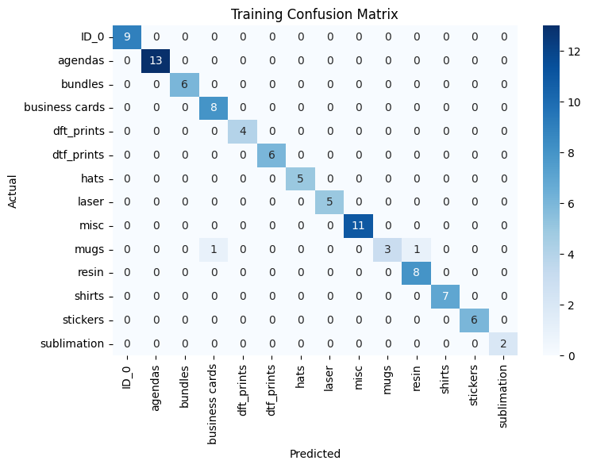

```
📋 Classification Report — Validation Set:

                precision    recall  f1-score   support

       agendas       0.50      1.00      0.67         1
business cards       0.00      0.00      0.00         1
    dtf_prints       1.00      1.00      1.00         3
          hats       0.00      0.00      0.00         1
          misc       1.00      1.00      1.00         1
          mugs       1.00      0.75      0.86         8
         resin       1.00      1.00      1.00         1
   sublimation       1.00      0.50      0.67         2

     micro avg       0.93      0.72      0.81        18
     macro avg       0.69      0.66      0.65        18
  weighted avg       0.86      0.72      0.77        18
```

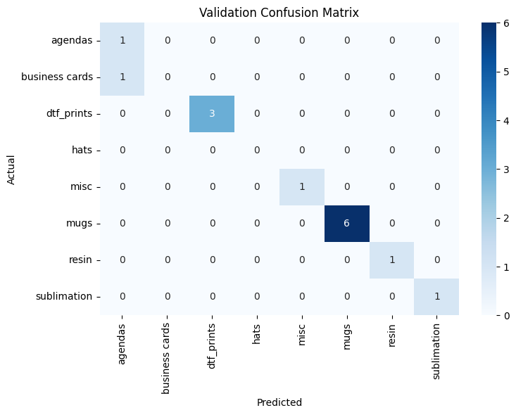

```
📋 Classification Report — Test Set:

                precision    recall  f1-score   support

       agendas       0.00      0.00      0.00         1
business cards       0.00      0.00      0.00         2
    dtf_prints       0.50      0.50      0.50         2
          hats       0.00      0.00      0.00         1
          misc       0.33      1.00      0.50         1
          mugs       1.00      0.44      0.62         9
         resin       0.00      0.00      0.00         1
   sublimation       0.50      1.00      0.67         1

     micro avg       0.41      0.39      0.40        18
     macro avg       0.29      0.37      0.29        18
  weighted avg       0.60      0.39      0.43        18
```

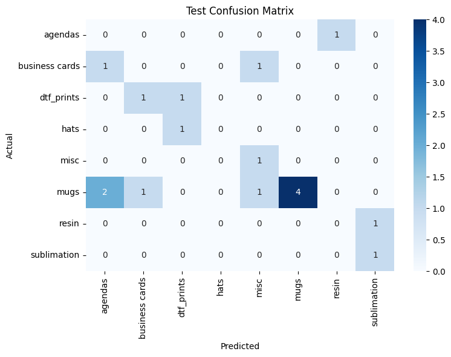

```python
# 1) Recompute class weights from train_df
class_counts = train_df['category_id'].value_counts().sort_index().values
class_weights = 1.0 / torch.tensor(class_counts, dtype=torch.float)
class_weights = class_weights / class_weights.sum() * len(class_counts)
class_weights = class_weights.to(device)

# 2) Create a sampler so that minority classes are oversampled
#    Sample weights per example = weight[class_id]
example_weights = class_weights[torch.tensor(train_df['category_id'].values)]
sampler = WeightedRandomSampler(
    weights=example_weights,
    num_samples=len(example_weights),
    replacement=True
)

# 3) Rebuild train_loader to use the sampler
train_loader = DataLoader(
    train_dataset,
    batch_size=32,
    sampler=sampler,    # ← replaces shuffle=True
    num_workers=2
)

# 4) Define weighted loss
criterion = nn.CrossEntropyLoss(weight=class_weights)

# 5) Re-train the model head with weighted loss
optimizer = torch.optim.Adam(model.fc.parameters(), lr=0.001)

num_epochs = 20
for epoch in range(num_epochs):
    model.train()
    running_loss = 0.0
    all_preds, all_labels = [], []

    for images, labels in train_loader:
        images, labels = images.to(device), labels.to(device)
        optimizer.zero_grad()
        outputs = model(images)
        loss = criterion(outputs, labels)
        loss.backward()
        optimizer.step()

        running_loss += loss.item() * images.size(0)
        preds = outputs.argmax(dim=1)
        all_preds.extend(preds.cpu().numpy())
        all_labels.extend(labels.cpu().numpy())

    epoch_loss = running_loss / len(train_loader.dataset)
    epoch_acc  = accuracy_score(all_labels, all_preds)
    print(f"Epoch {epoch+1:02d}/{num_epochs} — Loss: {epoch_loss:.4f} — Train Acc: {epoch_acc:.4f}")

    # Optional: run a quick validation pass each epoch
    model.eval()
    v_preds, v_labels = [], []
    with torch.no_grad():
        for imgs, lbls in val_loader:
            imgs, lbls = imgs.to(device), lbls.to(device)
            out = model(imgs)
            v_preds.extend(out.argmax(dim=1).cpu().numpy())
            v_labels.extend(lbls.cpu().numpy())
    val_acc = accuracy_score(v_labels, v_preds)
    print(f"           Validation Acc: {val_acc:.4f}\n")

# 6) Final evaluation on train/val/test with your utilities
train_true, train_pred = evaluate_torch(model, train_loader, device)
val_true,   val_pred   = evaluate_torch(model, val_loader,   device)
test_true,  test_pred  = evaluate_torch(model, test_loader,  device)

print_report(train_true, train_pred, index2name, "Training")
plot_cm(train_true, train_pred, index2name, "Training")

print_report(val_true, val_pred, index2name, "Validation")
plot_cm(val_true, val_pred, index2name, "Validation")

print_report(test_true, test_pred, index2name, "Test")
plot_cm(test_true, test_pred, index2name, "Test")
```

```python
# Save PyTorch model
torch.save(model.state_dict(), "final_model.pt")
print("✅ PyTorch model saved as 'final_model.pt'")
```

```python
# Save TensorFlow/Keras model
model.save("final_model.h5")
print("✅ TensorFlow model saved as 'final_model.h5'")
```

```python
# Export requirements to a file
!pip freeze > requirements.txt
print("✅ requirements.txt exported")
```

## 📌 Conclusion

Future work may involve:

Overall, this project demonstrates a complete ML pipeline—from preprocessing and training to evaluation and deployment-ready packaging.